# Lecture 7: Pandas

## Dealing with Missing Values and Duplicated Observations in Pandas

### Missing Data

- Missing data is a common issue in data analysis
- Consists of **non-existent** or **unobserved** data
- It is important to have a clear picture of missing data in the dataset under analysis:
  - Provides info of the representativeness of the data
  - Identifies potential biases that might invalidate the analysis
  - Might point towards data collection problems

### Missing Data in Pandas - Values and Methods

Pandas aims to simplify dealing with missing data

- There are two objects used as **sentinel values** for missing data:
  - `NaN` (Not a Number, from Numpy) to represent missing data for numeric values
  - `None`(from basic Python) to represent other missing data
  - This distinction is important for some operations, but these are mainly edge cases
- Pandas provides methods to handle missing data:
  - `isna` (`notna`) returns a Boolean Series indicating which values are (not) missing

### Identifying and Removing Missing Data

```python
ser_nan = pd.Series([1.2, np.nan, None,  -3.5, 2, 0], index=["a", "b", np.nan, "d", np.nan, "f"])
print(f"The series ser_nan is:\n{ser_nan}\n")
print(f"The command ser_nan.isna() returns a boolean Series with True for NaN values: \n{ser_nan.isna()}\n")
print(f"The command ser_nan.isna().sum() easily computes the number of NaN values: \n{ser_nan.isna().sum()}\n")
```

```
The series ser_nan is:
a      1.2
b      NaN
NaN    NaN
d     -3.5
NaN    2.0
f      0.0
dtype: float64

The command ser_nan.isna() returns a boolean Series with True for NaN values:
a      False
b       True
NaN     True
d      False
NaN    False
f      False
dtype: bool

The command ser_nan.isna().sum() easily computes the number of NaN values:
2
```

### Filtering Missing Data in Series

- To Filter Missing Data:
  - Manual filtering using `isna`/`notna` and Boolean indexing
  - Automated approach using `dropna` method
- `dropna` on a Series only return elements that have non-missing value
- The `inplace` parameter allows to modify the Series in place

### Filtering Missing Data in Series

```python
print(f"The series ser_nan is:\n{ser_nan}\n")
print(f"The command ser_nan[ser_nan.notna()] returns it with NaN values removed: \n{ser_nan[ser_nan.notna()]}\n")
print(f"The command ser_nan.dropna() returns it with NaN values removed: \n{ser_nan.dropna()}\n")
```

```
The series ser_nan is:
a      1.2
b      NaN
NaN    NaN
d     -3.5
NaN    2.0
f      0.0
dtype: float64

The command ser_nan[ser_nan.notna()] returns it with NaN values removed:
a      1.2
d     -3.5
NaN    2.0
f      0.0
dtype: float64

The command ser_nan.dropna() returns it with NaN values removed:
a      1.2
d     -3.5
NaN    2.0
f      0.0
dtype: float64
```

### Filtering Missing Data in DataFrames

- Removing missing data in dataFrames offers more options:
  - `axis={0,1}` sets whether to drop rows or columns
  - `how={any, all}` sets whether to drop a row/column that have any/all NA
  - `thresh` sets the minimum number of non-NA values required to keep a row/column

### Filtering Missing Data in DataFrames

```python
df_nan = pd.DataFrame({'A': [4, 1, 3, np.nan],'B': [3, np.nan, 2, np.nan],'C': [3, np.nan, 1, np.nan],'D': [1, 2, np.nan, np.nan]})
print(f"DataFrame df_nan:\n{df_nan}\n")
print(f"The command df_nan.dropna() drops all rows with any NaN values: \n{df_nan.dropna()}\n")
```

```
DataFrame df_nan:
     A    B    C    D
0  4.0  3.0  3.0  1.0
1  1.0  NaN  NaN  2.0
2  3.0  2.0  1.0  NaN
3  NaN  NaN  NaN  NaN

The command df_nan.dropna() drops all rows with any NaN values:
     A    B    C    D
0  4.0  3.0  3.0  1.0
```

### Filtering Missing Data in DataFrames

```python
print(f"DataFrame df_nan:\n{df_nan}\n")
print(f"df_nan.dropna(axis=0, how='all') drops all rows with all NaN values: \n{df_nan.dropna(axis=0, how='all')}\n")
print(f"df_nan.dropna(axis=1, thresh=3) drops all columns with less than three non-NaN values: \n{df_nan.dropna(axis=1, thresh=3)}\n")
```

```
DataFrame df_nan:
     A    B    C    D
0  4.0  3.0  3.0  1.0
1  1.0  NaN  NaN  2.0
2  3.0  2.0  1.0  NaN
3  NaN  NaN  NaN  NaN

df_nan.dropna(axis=0, how='all') drops all rows with all NaN values:
     A    B    C    D
0  4.0  3.0  3.0  1.0
1  1.0  NaN  NaN  2.0
2  3.0  2.0  1.0  NaN

df_nan.dropna(axis=1, thresh=3) drops all columns with less than three non-NaN values:
     A
0  4.0
1  1.0
2  3.0
3  NaN
```

### Filling Missing Data in DataFrames

In some cases it is better to fill missing data instead of dropping them

- `fillna` fills missings with a specific value
  - The mean and the median are used in many applications
- Nearby (and thus possibly related) observations can be used to fill missing:
  - `bfill` uses backwards obs
  - `ffill` uses forward obs
  - `interpolate` interpolates obs
  - `limit` allows to limit the number of consecutive missing values that will be filled

### Filling Missing Data in DataFrames - Fill with a Set Value: `fillna`

```python
print(f"DataFrame df_nan:\n{df_nan}\n")
print(f"df_nan.fillna(0) fills all NaN values with 0: \n{df_nan.fillna(0)}\n")
print(f"df_nan.fillna(df_nan.mean()) fills all NaN values with the mean of the column: \n{df_nan.fillna(df_nan.mean())}\n")
```

```
DataFrame df_nan:
     A    B    C    D
0  4.0  3.0  3.0  1.0
1  1.0  NaN  NaN  2.0
2  3.0  2.0  1.0  NaN
3  NaN  NaN  NaN  NaN

df_nan.fillna(0) fills all NaN values with 0:
     A    B    C    D
0  4.0  3.0  3.0  1.0
1  1.0  0.0  0.0  2.0
2  3.0  2.0  1.0  0.0
3  0.0  0.0  0.0  0.0

df_nan.fillna(df_nan.mean()) fills all NaN values with the mean of the column:
          A    B    C    D
0  4.000000  3.0  3.0  1.0
1  1.000000  2.5  2.0  2.0
2  3.000000  2.0  1.0  1.5
3  2.666667  2.5  2.0  1.5
```

### Filling Missing Data in DataFrames - Backward and Forward Filling: `bfill` and `ffill`

```python
print(f"DataFrame df_nan:\n{df_nan}\n")
print(f"df_nan.ffill() forward-fills the first NaN value : \n{df_nan.ffill(limit=1)}\n")
print(f"df_nan.bfill() backward-fills all NaN values: \n{df_nan.bfill()}\n")
```

```
DataFrame df_nan:
     A    B    C    D
0  4.0  3.0  3.0  1.0
1  1.0  NaN  NaN  2.0
2  3.0  2.0  1.0  NaN
3  NaN  NaN  NaN  NaN

df_nan.ffill() forward-fills the first NaN value :
     A    B    C    D
0  4.0  3.0  3.0  1.0
1  1.0  3.0  3.0  2.0
2  3.0  2.0  1.0  2.0
3  3.0  2.0  1.0  NaN

df_nan.bfill() backward-fills all NaN values:
     A    B    C    D
0  4.0  3.0  3.0  1.0
1  1.0  2.0  1.0  2.0
2  3.0  2.0  1.0  NaN
3  NaN  NaN  NaN  NaN
```

### Filling Missing Data in DataFrames - Filling by interpolation: `interpolate`

- If there are no backward values `bfill` is used
- If there are no forward values `ffill` is used

```python
print(f"DataFrame df_nan:\n{df_nan}\n")
print(f"df_nan.interpolate() interpolates NaN values: \n{df_nan.interpolate()}\n")
```

```
DataFrame df_nan:
     A    B    C    D
0  4.0  3.0  3.0  1.0
1  1.0  NaN  NaN  2.0
2  3.0  2.0  1.0  NaN
3  NaN  NaN  NaN  NaN

df_nan.interpolate() interpolates NaN values:
     A    B    C    D
0  4.0  3.0  3.0  1.0
1  1.0  2.5  2.0  2.0
2  3.0  2.0  1.0  2.0
3  3.0  2.0  1.0  2.0
```

### Filling Missing Data in DataFrames - the `axis` Parameter

- The `axis` parameter allows to specify whether to fill by column (`axis={0, rows}`, default) or by row (`axis={1, columns}`)

```python
print(f"DataFrame df_nan:\n{df_nan}\n")
print(f"df_nan.ffill(limit=1, axis='columns') forward-fills the first NaN value by row: \n{df_nan.ffill(limit=1, axis='columns')}\n")
```

```
DataFrame df_nan:
     A    B    C    D
0  4.0  3.0  3.0  1.0
1  1.0  NaN  NaN  2.0
2  3.0  2.0  1.0  NaN
3  NaN  NaN  NaN  NaN

df_nan.ffill(limit=1, axis='columns') forward-fills the first NaN value by row:
     A    B    C    D
0  4.0  3.0  3.0  1.0
1  1.0  1.0  NaN  2.0
2  3.0  2.0  1.0  1.0
3  NaN  NaN  NaN  NaN
```

### Filling Missing Data in DataFrames - the `axis` Parameter

- The `axis` parameter allows to specify whether to fill by column (`axis={0, rows}`, default) or by row (`axis={1, columns}`)

```python
print(f"DataFrame df_nan:\n{df_nan}\n")
print(f"df_nan.interpolate(axis=1) interpolates NaN values by row: \n{df_nan.interpolate(axis=1)}\n")
```

```
DataFrame df_nan:
     A    B    C    D
0  4.0  3.0  3.0  1.0
1  1.0  NaN  NaN  2.0
2  3.0  2.0  1.0  NaN
3  NaN  NaN  NaN  NaN

df_nan.interpolate(axis=1) interpolates NaN values by row:
     A         B         C    D
0  4.0  3.000000  3.000000  1.0
1  1.0  1.333333  1.666667  2.0
2  3.0  2.000000  1.000000  1.0
3  NaN       NaN       NaN  NaN
```

### Identifying and Removing Duplicates

```python
df_dup = pd.DataFrame({"col1": ["a", "b", "a", "a", "b"],  "col2": [1, 1, 2, 1, 1]})
print(f"DataFrame df_dup:\n{df_dup}\n")
print(f"df_dup.duplicated() returns a boolean Series with True for duplicated rows: \n{df_dup.duplicated()}\n")
print(f"df_dup.drop_duplicates() drops duplicated rows: \n{df_dup.drop_duplicates()}\n")
```

```
DataFrame df_dup:
  col1  col2
0    a     1
1    b     1
2    a     2
3    a     1
4    b     1

df_dup.duplicated() returns a boolean Series with True for duplicated rows:
0    False
1    False
2    False
3     True
4     True
dtype: bool

df_dup.drop_duplicates() drops duplicated rows:
  col1  col2
0    a     1
1    b     1
2    a     2
```

### Identifying and Removing Duplicates Based on a Subset of Columns

```python
df2_dup = pd.DataFrame({"col1": ["a", "b", "a", "a", "b"],  "col2": [1, 1, 2, 1, 1], "col3": np.arange(5)})
print(f"DataFrame df_dup:\n{df2_dup}\n")
print(f"The command df2_dup.drop_duplicates() drops duplicated rows: \n{df2_dup.drop_duplicates()}\n")
print(f"The command df2_dup.drop_duplicates(subset=['col1', 'col2']) drops rows if the columns ['col1', 'col2'] are duplicated: \n{df2_dup.drop_duplicates(subset=['col1', 'col2'])}\n")
```

```
DataFrame df_dup:
  col1  col2  col3
0    a     1     0
1    b     1     1
2    a     2     2
3    a     1     3
4    b     1     4

The command df2_dup.drop_duplicates() drops duplicated rows:
  col1  col2  col3
0    a     1     0
1    b     1     1
2    a     2     2
3    a     1     3
4    b     1     4

The command df2_dup.drop_duplicates(subset=['col1', 'col2']) drops rows if the columns ['col1', 'col2'] are duplicated:
  col1  col2  col3
0    a     1     0
1    b     1     1
2    a     2     2
```

### Duplicated Index Labels in Pandas

- Using duplicate index labels it's generally not recommended as data selection becomes messy
  - Indexing a label with multiple entries returns a Series
  - Indexing a label with a single entry returns a scalar value
- Usually happens because of a mis-specified multi-index
  - e.g., it shoud be obs-year but it is only obs
- **If you are getting unexpected results, check if your labels are unique**
  - The `is_unique` property can be used to check if axis labels are unique

```python
ser7 = pd.Series(np.arange(5), index=["a", "a", "b", "b", "c"])
print(f"Series with duplicate index labels: \n{ser7}\n")
print(f"ser7.index.is_unique checks for unique index labels and returns: {ser7.index.is_unique}\n")
```

```
Series with duplicate index labels:
a    0
a    1
b    2
b    3
c    4
dtype: int64

ser7.index.is_unique checks for unique index labels and returns: False
```

### Duplicated Index Labels in Pandas

```python
# Data selection with duplicate labels
print(f"ser7['a'] returns a Series when the index label is duplicated: \n{ser7['a']}\n")
print(f"ser7['c'] returns a scalar when the index label is unique: {ser7['c']}\n")
```

```
ser7['a'] returns a Series when the index label is duplicated:
a    0
a    1
dtype: int64

ser7['c'] returns a scalar when the index label is unique: 4
```

## Data Loading and Writing

## Data Loading and Writing

- Data loading is a necessary initial step in (almost) any data analysis
- The main categories of Input/Output (I/O) operations are:
  1. Reading/writing text files and (more efficient) formats stored on the computer
  2. Loading/updating data from databases
  3. Interfacing with network sources like APIs and web scraping
- We will have a quick look at the first point
- More resources on this topic: [Ch.6 of Python for Data Analysis](https://wesmckinney.com/book/accessing-data)

### Data Loading and Writing in Pandas

- Pandas provides several methods to handle various data formats
  - CSV, Excel, JSON, HTML, SQL, etc.

### Pandas Data Loading Functions

| Function | Description |
| --- | --- |
| `read_csv` | Load delimited data from a file, URL, or file-like object; use comma as default delimiter |
| `read_excel` | Read tabular data from an Excel XLS or XLSX file |
| `read_fwf` | Read data in fixed-width column format (i.e., no delimiters) |
| `read_pickle` | Read an object stored by pandas using the Python pickle format |
| `read_parquet` | Read the Apache Parquet binary file format |
| `read_json` | Read data from a JSON (JavaScript Object Notation) string representation, file, URL, or file-like object |
| `read_sas` | Read a SAS dataset stored in one of the SAS system's custom storage formats |
| `read_spss` | Read a data file created by SPSS |
| `read_sql` | Read the results of a SQL query (using SQLAlchemy) |
| `read_sql_table` | Read a whole SQL table (using SQLAlchemy); equivalent to using a query that selects everything in that table using `read_sql` |
| `read_stata` | Read a dataset from Stata file format |
| `read_xml` | Read a table of data from an XML file |
| `read_feather` | Read the Feather binary file format |
| `read_clipboard` | Variation of `read_csv` that reads data from the clipboard; useful for converting tables from web pages |
| `read_hdf` | Read HDF5 files written by pandas |
| `read_html` | Read all tables found in the given HTML document |
| `read_orc` | Read the Apache ORC binary file format |

### Handling Complex Data Encoded as Text with Pandas

- Pandas provides **many** optional arguments in data loading functions
  - Real-world data is often complex and these parameters allows to handle various scenarios
  - `pandas.read_csv` has around 50 optional parameters
    - Text-encoded data is very common and text has not been designed for data storage
- The complexity of data loading function can be overwhelming
  - The [pandas documentation on data loading functions](https://pandas.pydata.org/docs/reference/io.html) provides extensive examples
  - If you face difficulties in reading a file, there is probably a relevant example that can provide insights

### Optional Arguments in Data Loading Functions

- Arguments for: **Indexing and naming**
  - Allows to set one or more columns as the DataFrame index
  - There are options to get the column names from the file, from provided arguments, or use a numeric index (default)

### Optional Arguments in Data Loading Functions

- Arguments for: **Type Inference and Data Conversion**
  - Purposefully designed data formats (e.g., pickle, excel) store data types, so loading is easy
    - For other formats (e.g., csv), the type of each column is not specified
    - In these cases pandas tries to guess the data type of each column
    - Usually it works but, if needed, pandas allows to specify the type by column
      - Allow to perform user-defined value conversions (flag-values)
      - Customization for handling missing value markers

### Optional Arguments in Data Loading Functions

- **Date and Time Parsing**
  - Features for combining date and time information
  - Ability to merge data spread across multiple columns into a single column
- **Iterating**
  - Support for processing large files by dividing them into chunks
- **Handling Unclean Data**
  - Options for skipping rows, footers, or comments
  - Capabilities to deal with minor data issues like numeric data with comma-separated thousands

### Exploring Data Loading Functions Arguments with Examples

- We will now explore some of the most common arguments in data loading functions

### Some Examples of Data Loading from Text Files - ex1.csv

- Here the first example of textual data file (ex1.csv) opened with a text editor
- IT is a comma-separated-value CSV file with a header row and 3 rows of data

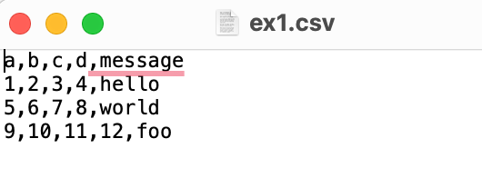

### Setting up Our Working Environment

- **Using Relative Paths**: We'll use relative paths to access files, ensuring portability.
- **Folder Structure**: Place the `example` folder in the same location as your script.
  - Files in this folder can then be accessed using `example/filename`.

### Loading csv Files - `read_csv`

```python
# reads the file marketing_rawData.csv
print(f"The command pd.read_csv('examples/ex1.csv')  reads the data from ex1.csv using default arguments:")
pd.read_csv('examples/ex1.csv')
```

```
The command pd.read_csv('examples/ex1.csv')  reads the data from ex1.csv using default arguments:
```

|  | a | b | c | d | message |
| --- | --- | --- | --- | --- | --- |
| 0 | 1 | 2 | 3 | 4 | hello |
| 1 | 5 | 6 | 7 | 8 | world |
| 2 | 9 | 10 | 11 | 12 | foo |

### Loading a csv File with no Header

Sometimes data files do not have a header row

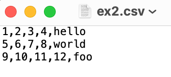

- In these cases Pandas would mistakenly use the first row as header
- The most common solutions are:
  1. Let Pandas assign default column names (integers starting at 0)
  2. Specify the column names using the `names` parameter

### Loading a csv File with no Header

```python
print(f"Using pd.read_csv('examples/ex2.csv'), pandas takes the first row as the header:\n")
pd.read_csv('examples/ex2.csv')
```

```
Using pd.read_csv('examples/ex2.csv'), pandas takes the first row as the header:
```

|  | 1 | 2 | 3 | 4 | hello |
| --- | --- | --- | --- | --- | --- |
| 0 | 5 | 6 | 7 | 8 | world |
| 1 | 9 | 10 | 11 | 12 | foo |

### Loading a csv File with no Header - Default Column Names - `Header=None`

```python
print(f"Using pd.read_csv(examples/ex2.csv'), header=None), pandas sets the default column names:")
pd.read_csv('examples/ex2.csv', header=None)
```

```
Using pd.read_csv(examples/ex2.csv'), header=None), pandas sets the default column names:
```

|  | 0 | 1 | 2 | 3 | 4 |
| --- | --- | --- | --- | --- | --- |
| 0 | 1 | 2 | 3 | 4 | hello |
| 1 | 5 | 6 | 7 | 8 | world |
| 2 | 9 | 10 | 11 | 12 | foo |

### Loading a csv File with no Header - Assign Column Names - `names`

```python
print(f"Using pd.read_csv('examples/ex2.csv', names = ['a', 'b', 'c', 'd', 'message'])\npandas sets the provided column names:")
pd.read_csv('examples/ex2.csv', names = ['a', 'b', 'c', 'd', 'message'])
```

```
Using pd.read_csv('examples/ex2.csv', names = ['a', 'b', 'c', 'd', 'message'])
pandas sets the provided column names:
```

|  | a | b | c | d | message |
| --- | --- | --- | --- | --- | --- |
| 0 | 1 | 2 | 3 | 4 | hello |
| 1 | 5 | 6 | 7 | 8 | world |
| 2 | 9 | 10 | 11 | 12 | foo |

### Loading a csv File - Setting a Column as Index - `index_col`

- The `index_col` parameter allows to set a column as index
  - Passing a list of column names creates a hierarchical index

```python
print(f"""Using the command
pd.read_csv('examples/ex2.csv', names = ['a', 'b', 'c', 'd', 'message'], index_col = 'message')
pandas sets the provided column names and the 'message' column as index:""")
pd.read_csv('examples/ex2.csv', names = ['a', 'b', 'c', 'd', 'message'], index_col = 'message')
```

```
Using the command
pd.read_csv('examples/ex2.csv', names = ['a', 'b', 'c', 'd', 'message'], index_col = 'message')
pandas sets the provided column names and the 'message' column as index:
```

| message | a | b | c | d |
| --- | --- | --- | --- | --- |
| hello | 1 | 2 | 3 | 4 |
| world | 5 | 6 | 7 | 8 |
| foo | 9 | 10 | 11 | 12 |

### Loading a Text File with a Custom Separator - `sep`

- Some text-format data file uses a given character as delimiter (e.g., csv use commas, tsv use tabs, etc.)
  - In these cases you can use the `sep` parameter to specify the delimiter (`sep = \t`)
- Sep also accepts regular expressions to handle more complex cases
  - Regular expressions are a powerful tool for pattern matching
    - E.g., `\s+` matches any whitespace character (space, tab, newline, etc.), `;|,` matches a semicolon or a comma
  - Regular expressions are a very powerful tool, but also very complex
    - AI is very good to come up with them, but you need to know what/how to ask
    - You can start learning and test RegEx here: [regex101](https://regex101.com/)

### Loading a Text File with Variable Whitespace as Delimiters

- Data in textual format may use variable whitespace

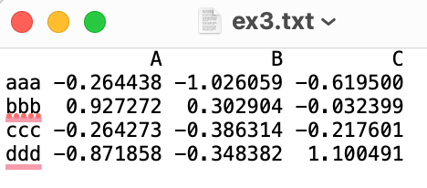

- We can then use the regular expression `\s+` to handle this case

### Loading a Text File with Variable Whitespace as Delimiters

```python
print(f"The command\npd.read_csv('examples/ex3.txt', sep='\s+')\nreads the data from ex3.txt allowing for arbitrary withspace delimitation:")
pd.read_csv('examples/ex3.txt', sep='\s+')
```

```
The command
pd.read_csv('examples/ex3.txt', sep='\s+')
reads the data from ex3.txt allowing for arbitrary withspace delimitation:
```

|  | A | B | C |
| --- | --- | --- | --- |
| aaa | -0.264438 | -1.026059 | -0.619500 |
| bbb | 0.927272 | 0.302904 | -0.032399 |
| ccc | -0.264273 | -0.386314 | -0.217601 |
| ddd | -0.871858 | -0.348382 | 1.100491 |

- Note that the first column is now the index
  - This is done automatically by Pandas when the file has a number of data columns that is that is 1 more than the length of the header columns

### Loading a Text with a Preamble or Comments - `skiprows`

- Often there are lines at the beginning of the file that are not part of the data
  - E.g., a description of the data or its source

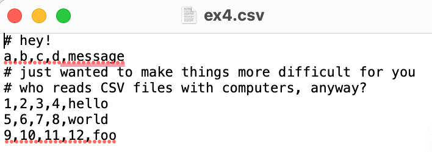

- These lines can be skipped using the `skiprows` parameter

### Loading a Text with a Preamble or Comments - `skiprows`

```python
print(f"The command\npd.read_csv('examples/ex4.csv')\nreads the data and tries to fit it into a table (with questionable results):")
pd.read_csv('examples/ex4.csv')
```

```
The command
pd.read_csv('examples/ex4.csv')
reads the data and tries to fit it into a table (with questionable results):
```

|  |  |  |  | # hey! |
| --- | --- | --- | --- | --- |
| a | b | c | d | message |
| # just wanted to make things more difficult for you | NaN | NaN | NaN | NaN |
| # who reads CSV files with computers | anyway? | NaN | NaN | NaN |
| 1 | 2 | 3 | 4 | hello |
| 5 | 6 | 7 | 8 | world |
| 9 | 10 | 11 | 12 | foo |

### Loading a Text with a Preamble or Comments - `skiprows`

```python
print(f"The command\npd.read_csv('examples/ex4.csv', skiprows=[0, 2, 3])\nallows to skip the selected rows:")
pd.read_csv('examples/ex4.csv', skiprows=[0, 2, 3])
```

```
The command
pd.read_csv('examples/ex4.csv', skiprows=[0, 2, 3])
allows to skip the selected rows:
```

|  | a | b | c | d | message |
| --- | --- | --- | --- | --- | --- |
| 0 | 1 | 2 | 3 | 4 | hello |
| 1 | 5 | 6 | 7 | 8 | world |
| 2 | 9 | 10 | 11 | 12 | foo |

### Handling Missing Values in File Reading

- Missing data handling is crucial in file reading
- Missing values typically appear as empty strings or sentinel values
- Pandas has a set of sentinel values that are recognized as missing values by default:
  - E.g., `NaN`, `NA`, `-1.#IND`, `1.#QNAN`, `1.#IND`, `-1.#QNAN`, `#N/A N/A`, `#N/A`, `N/A`, `n/a`, `NA`, `<NA>`, `#NA`, `NULL`, `null`, `NaN`, `-NaN`, `nan`, `-nan`, ``
- The `na_values` parameter allows to specify **additional** strings to be recognized as missing values
- Specifying `keep_default_na=False` allows to not consider the default sentinel values

### Loading a Text with Missing Values

- Consider for example the following dataset
  - It has one NA value in the row 1 and an empty string in row 2

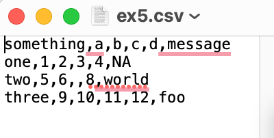

### Loading a Text with Missing Values

```python
print(f"The command\npd.read_csv('examples/ex5.csv')\nreads the data and converts to NaN the default sentinel values:")
pd.read_csv('examples/ex5.csv')
```

```
The command
pd.read_csv('examples/ex5.csv')
reads the data and converts to NaN the default sentinel values:
```

|  | something | a | b | c | d | message |
| --- | --- | --- | --- | --- | --- | --- |
| 0 | one | 1 | 2 | 3.0 | 4 | NaN |
| 1 | two | 5 | 6 | NaN | 8 | world |
| 2 | three | 9 | 10 | 11.0 | 12 | foo |

### Loading a Text with Missing Values - `keep_default_na`

```python
print(f"The command\npd.read_csv('examples/ex5.csv', keep_default_na=False)\ndoes not convert any value to NaN:")
pd.read_csv('examples/ex5.csv', keep_default_na=False)
```

```
The command
pd.read_csv('examples/ex5.csv', keep_default_na=False)
does not convert any value to NaN:
```

|  | something | a | b | c | d | message |
| --- | --- | --- | --- | --- | --- | --- |
| 0 | one | 1 | 2 | 3 | 4 | NA |
| 1 | two | 5 | 6 |  | 8 | world |
| 2 | three | 9 | 10 | 11 | 12 | foo |

### Loading a Text with Missing Values - `keep_default_na` and `na_values`

```python
print(f"The command\npd.read_csv('examples/ex5.csv', keep_default_na=False, na_values = ['NA'])\nconverts to NaN only the supplied sentinel values:")
pd.read_csv('examples/ex5.csv', keep_default_na=False, na_values = ['NA'])
```

```
The command
pd.read_csv('examples/ex5.csv', keep_default_na=False, na_values = ['NA'])
converts to NaN only the supplied sentinel values:
```

|  | something | a | b | c | d | message |
| --- | --- | --- | --- | --- | --- | --- |
| 0 | one | 1 | 2 | 3 | 4 | NaN |
| 1 | two | 5 | 6 |  | 8 | world |
| 2 | three | 9 | 10 | 11 | 12 | foo |

### Loading a Text with Missing Values - `keep_default_na` and `na_values` by Column

```python
sentinels = {"message": ["foo", "NA"], "something": ["two"]}
print(f"We define the sentinels dictionary as:\n{sentinels}\n")
print(f"""The command
pd.read_csv('examples/ex5.csv', keep_default_na=False, na_values=sentinels)
converts to NaN only the supplied sentinel values distinguishing by column:""")
pd.read_csv('examples/ex5.csv', keep_default_na=False, na_values=sentinels)
```

```
We define the sentinels dictionary as:
{'message': ['foo', 'NA'], 'something': ['two']}

The command
pd.read_csv('examples/ex5.csv', keep_default_na=False, na_values=sentinels)
converts to NaN only the supplied sentinel values distinguishing by column:
```

|  | something | a | b | c | d | message |
| --- | --- | --- | --- | --- | --- | --- |
| 0 | one | 1 | 2 | 3 | 4 | NaN |
| 1 | NaN | 5 | 6 |  | 8 | world |
| 2 | three | 9 | 10 | 11 | 12 | NaN |

### Useful Arguments for `read.csv`

| Argument | Description |
| --- | --- |
| path | String indicating filesystem location, URL, or file-like object. |
| sep or delimiter | Character sequence or regular expression to use to split fields in each row. |
| header | Row number to use as column names; defaults to 0 (first row), but should be None if there is no header row. |
| index_col | Column numbers or names to use as the row index in the result; can be a single name/number or a list of them for a hierarchical index. |
| names | List of column names for result. |
| skiprows | Number of rows at beginning of file to ignore or list of row numbers (starting from 0) to skip. |
| na_values | Sequence of values to replace with NA. They are added to the default list unless keep_default_na=False is passed. |
| keep_default_na | Whether to use the default NA value list or not (True by default). |
| comment | Character(s) to split comments off the end of lines. |
| parse_dates | Attempt to parse data to datetime; False by default. If True, will attempt to parse all columns. Otherwise, can specify a list of column numbers or names to parse. If element of list is tuple or list,… |
| keep_date_col | If joining columns to parse date, keep the joined columns; False by default. |
| converters | Dictionary containing column number or name mapping to functions (e.g., {"foo": f} would apply the function f to all values in the "foo" column). |
| dayfirst | When parsing potentially ambiguous dates, treat as international format (e.g., 7/6/2012 -> June 7, 2012); False by default. |
| date_parser | Function to use to parse dates. |
| nrows | Number of rows to read from beginning of file (not counting the header). |
| iterator | Return a TextFileReader object for reading the file piecemeal. This object can also be used with the with statement. |
| chunksize | For iteration, size of file chunks. |
| skip_footer | Number of lines to ignore at end of file. |
| verbose | Print various parsing information, like the time spent in each stage of the file conversion and memory use information. |
| encoding | Text encoding (e.g., "utf-8 for UTF-8 encoded text). Defaults to "utf-8" if None. |
| squeeze | If the parsed data contains only one column, return a Series. |
| thousands | Separator for thousands (e.g., "," or "."); default is None. |
| decimal | Decimal separator in numbers (e.g., "." or ","); default is ".". |
| engine | CSV parsing and conversion engine to use; can be one of "c", "python", or "pyarrow". The default is "c", though the newer "pyarrow" engine can parse some files much faster. The "python" engine is slow… |

### Writing Data to Text Files

- Data can be exported to a text delimited format using `to_csv`
- Main arguments:
  - The `path_or_buf` the filepath where to write the file
  - The `sep` parameter specifies the delimiter
    - The default is the comma
  - The `index` and `header` (`True/False`) set whether to write the index and header
    - The default is to write both
  - The `na_rep` parameter specifies the string to use in place of missing values
    - The default is to write them as empty strings
  - `columns` allows to specify the columns to be saved (and their order)
    - The default is to write all columns

### Writing Data to Text Files - `to_csv`

- We will be writing the dataframe of ex5
  1. We will load the data and apply convert NaN using a dictionary
  2. We will then save the data back

```python
df_ex5=pd.read_csv('examples/ex5.csv', keep_default_na=False, na_values = sentinels)
print(f"""The command
df_ex5=pd.read_csv('examples/ex5.csv', keep_default_na=False, na_values = sentinels)
converts to NaN only the supplied sentinel values distinguishing by column:""")
df_ex5
```

```
The command
df_ex5=pd.read_csv('examples/ex5.csv', keep_default_na=False, na_values = sentinels)
converts to NaN only the supplied sentinel values distinguishing by column:
```

|  | something | a | b | c | d | message |
| --- | --- | --- | --- | --- | --- | --- |
| 0 | one | 1 | 2 | 3 | 4 | NaN |
| 1 | NaN | 5 | 6 |  | 8 | world |
| 2 | three | 9 | 10 | 11 | 12 | NaN |

### Writing Data to Text Files - `to_csv`

```python
print(f"""Using the command
df_ex5.to_csv('examples/ex5_mod.csv', sep='\t', na_rep='NaN', index=False, columns=['a', 'b', 'c'])
the output file looks like this:""")
```

```
Using the command
df_ex5.to_csv('examples/ex5_mod.csv', sep='	', na_rep='NaN', index=False, columns=['a', 'b', 'c'])
the output file looks like this:
```

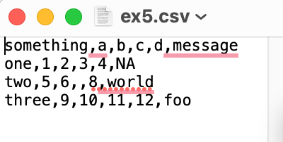

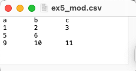

### Binary Data Formats - `Pickle`

- Binary data formats are typically more efficient to read and write
  - They are designed to store data as it appears in the computer's memory
  - They are not human-readable
- Storing data in binary format can be done using Python's `pickle` module
- You can read a pickle file using `read_pickle` and write it using `to_pickle`

### Saving and Loading Data in Binary Format - `to_pickle` and `read_pickle`

```python
df_ex5.to_pickle('examples/ex5_mod.pckl')
df_ex5_frompckl = pd.read_pickle('examples/ex5_mod.pckl')
print(f"The command df_ex5.to_pickle('examples/ex5_mod.pckl') saves the df_ex5 to a pckl file")
print(f"The command df_ex5_frompckl = pd.read_pickle('examples/ex5_mod.pckl') loads it back")
df_ex5_frompckl
```

```
The command df_ex5.to_pickle('examples/ex5_mod.pckl') saves the df_ex5 to a pckl file
The command df_ex5_frompckl = pd.read_pickle('examples/ex5_mod.pckl') loads it back
```

|  | something | a | b | c | d | message |
| --- | --- | --- | --- | --- | --- | --- |
| 0 | one | 1 | 2 | 3 | 4 | NaN |
| 1 | NaN | 5 | 6 |  | 8 | world |
| 2 | three | 9 | 10 | 11 | 12 | NaN |

### Reading Microsoft Excel Files

- Pandas supports reading data from Excel 2003 and newer files
- Requires additional packages `xlrd` for XLS files and `openpyxl` for XLSX files
- The function to use is `pandas.read_excel`
  - The `sheet_name` parameter allows to specify the sheet to read
    - Can be a string (sheet name) or an integer (sheet number)
    - The default is to read the first sheet

### Reading Microsoft Excel Files

Consider the following files:

[figure not shown]

[figure not shown]

### Reading Microsoft Excel Files

```python
print(f"""The command
pd.read_excel('examples/ex1.xlsx', index_col=0)
reads the first sheet from ex1.xlsx:""")
pd.read_excel('examples/ex1.xlsx', index_col=0)
```

```
The command
pd.read_excel('examples/ex1.xlsx', index_col=0)
reads the first sheet from ex1.xlsx:
```

|  | a | b | c | d | message |
| --- | --- | --- | --- | --- | --- |
| 0 | 1 | 2 | 3 | 4 | hello |
| 1 | 5 | 6 | 7 | 8 | world |
| 2 | 9 | 10 | 11 | 12 | foo |

### Reading Microsoft Excel Files

```python
print(f"""The command
pd.read_excel('examples/ex1.xlsx', sheet_name='Sheet2', index_col=0)
reads the second sheet from ex1.xlsx:""")
pd.read_excel('examples/ex1.xlsx', sheet_name='Sheet2', index_col=0)
```

```
The command
pd.read_excel('examples/ex1.xlsx', sheet_name='Sheet2', index_col=0)
reads the second sheet from ex1.xlsx:
```

|  | A | B | C | D | Text |
| --- | --- | --- | --- | --- | --- |
| i | 1 | 2 | 3 | 4 | hello |
| ii | 5 | 6 | 7 | 8 | world |
| iii | 9 | 10 | 11 | 12 | foo |

## Iteration and Vectorization in Pandas

### Iterating over Pandas DataFrames

- Iterating over Pandas DataFrames is **not recommended**
  - Pandas is optimized for vectorized operations - **iterating over rows is slow**
  - Still, iteration is the most flexible tool, so sometimes it is necessary
- You can iterate using any index method (bracket, `loc`, `iloc`)
  - The index method (`df.index`) returns a Series with the indexes for each row
  - You can use these indexes to select each row in a loop
- Iterrows is a specificaly designed method for iterating over rows
  - It returns a tuple of two elements containing the **index** and **row** values

### Iterating over Pandas DataFrames - Standard Indexing

```python
df_iter = pd.DataFrame({'Student': ['Alice', 'Bob', 'Charlie', 'Ethan', 'Diana'], 'Score': [85, 58, 90, 45, 73]})
print(f"The df_iter dataFrame is: \n{df_iter}\n")
for index in df_iter.index: # Loop over the index of the dataFrame
    print(f"Student at index {index} is {df_iter['Student'].iloc[index]} and scored {df_iter['Score'].iloc[index]}")
```

```
The df_iter dataFrame is:
   Student  Score
0    Alice     85
1      Bob     58
2  Charlie     90
3    Ethan     45
4    Diana     73

Student at index 0 is Alice and scored 85
Student at index 1 is Bob and scored 58
Student at index 2 is Charlie and scored 90
Student at index 3 is Ethan and scored 45
Student at index 4 is Diana and scored 73
```

### Iterating over Pandas DataFrames - `iterrows`

```python
print(f"The df_iter dataFrame is: \n{df_iter}\n")
for index, row in df_iter.iterrows():
    print(f"Student at index {index} is {row['Student']} and scored {row['Score']}")
```

```
The df_iter dataFrame is:
   Student  Score
0    Alice     85
1      Bob     58
2  Charlie     90
3    Ethan     45
4    Diana     73

Student at index 0 is Alice and scored 85
Student at index 1 is Bob and scored 58
Student at index 2 is Charlie and scored 90
Student at index 3 is Ethan and scored 45
Student at index 4 is Diana and scored 73
```

### DataFrame's Apply Method in Pandas

- The `apply` method in Pandas is the 'intended' way to apply functions to a DataFrame
- Not needed for array statistics commonly used(e.g., `sum` and `mean`)
  - `df.sum()` and `df.mean()` are equivalent to `df.apply(sum)` and `df.apply(mean)`
- Most useful with **user-defined functions**

### Advantages of Using Functions

- A function is a "chunk" of code that takes inputs (parameters) and provides an output (return value)
- In principle, it could be substituted by copy-pasting the code. **However functions allow for**:
  1. **Evocative Naming**: Can be assigned an evocative name, making the code easier to understand
  2. **Centralized Code Updates**: Only need to update code in one place when needed
  3. **Reduced Error Risk**: Eliminate the chance of incidental mistakes when copy-pasting
  4. **Exploit Pandas's `apply`**: Operate on the elements of multiple rows/columns without iteration
- **Best Practices**:
  - Functions should do **only one thing** and do it well
  - Create a function if you find yourself copying and pasting the same code more than twice

### Defining a Function in Python

```
def function_name(parameters, separated, by, commas):
    """docstring""" # to describe what the functions do - optional but advised
    body_doing_operations_on_parameters_and_storing_result
    return result
```

- `def`: Keyword to start a function definition
- `function_name`: Unique identifier for the function
- `parameters`: Variables to pass to the function
- `docstring`: Optional, for documentation of what the function does
- `body`: Code block where the function's tasks are performed
- `return`: Keyword to return a value from the function
  - if not specified the last line of the body is returned

### An Example of Function Definition in Python

- **Function `pass_or_fail`**:
  - input: `score` on the test
  - output: `"Pass"` if the score is above the `passing_threshold` and `"Fail"` otherwise

```python
def pass_or_fail(score, passing_threshold):
    """Determines if the score is a pass or fail based on the passing threshold.""" #Docstring describing the function
    if score < 0 or score > 100:                                                    #Check if the score has an admissible value
        return "Invalid score"                                                      #Of the score value is not admissible return "Invalid score"
    if score >= passing_threshold:                                                  #Check if the the score is bigger or equal to the passing_threshold
        return "PASSED"                                                             #If the the score is bigger or equal to the passing_threshold return "Passed"
    else:                                                                           #Otherwise
        return "FAILED"                                                             #Return "FAILED"
print(f"pass_or_fail(score=85, passing_threshold=60) returns: {pass_or_fail(score=85, passing_threshold=60)}")
print(f"pass_or_fail(score=50, passing_threshold=60) returns: {pass_or_fail(score=50, passing_threshold=60)}")
print(f"pass_or_fail(score=110, passing_threshold=60) returns: {pass_or_fail(score=110, passing_threshold=60)}")
```

```
pass_or_fail(score=85, passing_threshold=60) returns: PASSED
pass_or_fail(score=50, passing_threshold=60) returns: FAILED
pass_or_fail(score=110, passing_threshold=60) returns: Invalid score
```

### `apply` a Custom Function on a Series

Let's use the function `pass_or_fail` to create a new column identifying which students passed the test

```python
print(f"The df_iter dataFrame is: \n{df_iter}\n")
print(f"Running df_iter['Result'] = df_iter['Score'].apply(pass_or_fail, passing_threshold=55), creates a new column with the result of the function on the Score column\n")
df_iter['Result'] = df_iter['Score'].apply(pass_or_fail, passing_threshold=55)
print(f"The exam_results becomes: \n{df_iter}\n")
```

```
The df_iter dataFrame is:
   Student  Score
0    Alice     85
1      Bob     58
2  Charlie     90
3    Ethan     45
4    Diana     73

Running df_iter['Result'] = df_iter['Score'].apply(pass_or_fail, passing_threshold=55), creates a new column with the result of the function on the Score column

The exam_results becomes:
   Student  Score  Result
0    Alice     85  PASSED
1      Bob     58  PASSED
2  Charlie     90  PASSED
3    Ethan     45  FAILED
4    Diana     73  PASSED
```

### `map`: a Limited but Faster `apply`

- `apply` is **flexible**: can operate on multiple dataFrame columns and the function can take multiple arguments
- `map` is a simpler method that:
  - Only operates on **Series**
  - Only accepts single-argument functions
  - Is typically more efficient
- Use cases
  - Use `map` for single column transformations
  - Opt for `apply` in more elaborate cases

### `map` a Limited but Faster `apply`

- Let's define a simple function that extracts the last 3 characters of a string

```python
def lastThreeChars(x):
    """Returns the last three characters of a string."""
    return x[-3:]
print(f"Running df2['state'].map(lastThreeChars) returns: \n{df2['state'].map(lastThreeChars)}\n")
```

```
Running df2['state'].map(lastThreeChars) returns:
a    hio
b    hio
c    hio
d    ada
e    ada
f    ada
Name: state, dtype: object
```

### `apply` a Custom Function on a DataFrame - Using Multiple Columns

- `apply` allows to define functions that combine multiple columns
- Let's define a function that returns the ratio of two columns

```python
print(f"The function calculate_debt_to_income(row), calculates the ratio of the columns 'debt' and 'income'")
def calculate_debt_to_income(row):
    if row['income'] != 0:
        return row['debt'] / row['income']
    else:
        return np.nan
```

```
The function calculate_debt_to_income(row), calculates the ratio of the columns 'debt' and 'income'
```

### `apply` a Custom Function on a DataFrame - Using Multiple Columns

```python
print(f"df2 is:\n{df2}\n")
df2['debt_to_income'] = df2.apply(calculate_debt_to_income, axis=1)
print(f"df2['debt_to_income'] = df2.apply(calculate_debt_to_income, axis=1) creates a new column 'debt_to_income' in df2:\n{df2}")
```

```
df2 is:
   year   state      pop          debt  income
a  2000    Ohio  1500000  1.200000e+09     NaN
b  2001    Ohio  1700000  1.500000e+09  2000.0
c  2002    Ohio  3600000  1.700000e+09     NaN
d  2001  Nevada  2400000  5.000000e+08  3000.0
e  2002  Nevada  2900000  8.000000e+08     NaN
f  2003  Nevada  3200000  1.000000e+09  4000.0

df2['debt_to_income'] = df2.apply(calculate_debt_to_income, axis=1) creates a new column 'debt_to_income' in df2:
   year   state      pop          debt  income  debt_to_income
a  2000    Ohio  1500000  1.200000e+09     NaN             NaN
b  2001    Ohio  1700000  1.500000e+09  2000.0   750000.000000
c  2002    Ohio  3600000  1.700000e+09     NaN             NaN
d  2001  Nevada  2400000  5.000000e+08  3000.0   166666.666667
e  2002  Nevada  2900000  8.000000e+08     NaN             NaN
f  2003  Nevada  3200000  1.000000e+09  4000.0   250000.000000
```

### Lambda Functions in Python: Simplifying Short Operations

- Sometimes you only need to do an operation once
  - Defining a function in these cases is overkill
- Lambda functions are **anonymous functions** that can be defined in a single line
  - Ideal for simple, temporary functions
- Syntax:

  ```
  lambda parameters_separated_by_commas: body_doing_operations_on_parameters
  ```

- Consists of the `lambda` keyword, followed by **the parameters**, **a colon**, and **an expression**
  - Can have any number of parameters but only one expression
  - The expression is evaluated and returned

### Lambda Functions in Python: Simplifying Short Operations - An Example

```python
print(f"Running df2['state'].apply(lambda x: x[-3:]) returns: \n{df2['state'].apply(lambda x: x[-3:])}\n")
```

```
Running df2['state'].apply(lambda x: x[-3:]) returns:
a    hio
b    hio
c    hio
d    ada
e    ada
f    ada
Name: state, dtype: object
```

### 📊 Exercise: Functions, Apply, Map, Sorting, and Ranking

- Exercise 1: Salary Category
1. Write a function named `salary_category` that categorizes salaries into 'Low', 'Medium', and 'High'. Use thresholds at $50,000$ and $70,000 for the categories.
2. Apply this function to the 'Salary' column of a DataFrame that contains 'Age' and 'Salary' of individuals.
3. Add a new column to the DataFrame called 'Category' which shows the salary categories for each row. Display the updated DataFrame.

```
data1 = pd.DataFrame({
    'Age': [25, 30, 45, 28, 35],
    'Salary': [50000, 55000, 80000, 45000, 70000]
})
```

- Exercise 2: Product Quality Assessment
1. Create a function `quality_assessment` that takes a score (0-100) and returns 'Poor', 'Average', 'Good', or 'Excellent' based on two thresholds to be provided as arguments.
2. Apply this function to each row of a DataFrame that contains product names and their quality scores.
3. Add a new column 'Quality' to the DataFrame that displays the quality assessment for each product. Show the updated DataFrame.

```
data2 = pd.DataFrame({
    'Product': ['Widget', 'Gadget', 'Thingamajig', 'Doohickey', 'Gizmo'],
    'Quality_Score': [85, 58, 75, 45, 93]
})
```

- Exercise 3: Product Pricing Analysis
1. Use lambda functions to ensure the 'Price' column is of float type and the 'Quantity' column is of integer type in a DataFrame that contains products, their prices, quantities, and discount availability.
2. Write a lambda function to convert the 'Discount' column to boolean values (True for 'Yes', False for 'No').
3. Create a function `total_sales` that calculates the total sales (price * quantity) and applies a 10% discount if the discount is True.
4. Apply `total_sales` to each row of the DataFrame and add a new column 'Total_Sales'. Display the DataFrame with this new column.

```
data3 = pd.DataFrame({
    'Product': ['Apple', 'Banana', 'Carrot', 'Date', 'Eggplant'],
    'Price': [1.5, 0.5, 2.0, 3.0, 4.5],
    'Quantity': [10, 20, 15, 5, 7],
    'Discount': ['Yes', 'No', 'Yes', 'No', 'Yes']
})
```

- Exercise 4: Trimmed Mean Comparison Across Products
1. Write a function named `trimmed_mean` that calculates the trimmed mean of a list of numbers. The function should take two parameters: the list of numbers and the number of values to trim from each end. For example, trim = 5 would remove the lowest 5 and the highest 5 values.
2. Apply this function to the columns of a DataFrame, each representing the sales figures for different products over a period. Compare the trimmed means to evaluate the performance consistency of the products.
3. Order the columns of the DataFrame by their trimmed means in ascending order. Display the DataFrame with the ordered columns.

```
data4 = pd.DataFrame({
    'Product_A': [120, 110, 130, 115, 125, 140, 135, 150, 145, 155],
    'Product_B': [200, 210, 190, 205, 195, 180, 185, 175, 170, 160],
    'Product_C': [300, 310, 320, 305, 295, 285, 275, 265, 255, 245]
})
```

- Exercise 5: Advanced Facility Efficiency Analysis
1. Create a function named `efficiency_score` that computes an efficiency score for each facility. The score should be based on a combination of parameters like energy usage, output, and operational hours. The function should take these parameters as input and return a calculated score. You are left to decide the exact formula for the score, make it relevant!
2. Apply this function to each row of a DataFrame where each row represents different facilities with their respective energy usage, output, and operational hours.
3. Add a new column 'Efficiency_Score' to the DataFrame that contains the computed scores. Use these scores to show (order) which facility is operating most efficiently.

```
data5 = pd.DataFrame({
    'Facility': ['Alpha', 'Beta', 'Gamma', 'Delta', 'Epsilon'],
    'Energy_Usage': [2000, 1800, 2200, 2100, 1900],  # Energy usage in kWh
    'Output': [400, 350, 450, 425, 375],  # Output in units
    'Operational_Hours': [50, 48, 55, 52, 49]  # Hours per week
})
```

## Group Operations in Pandas

### Group Operations

- Group operations:
  - **Split** a dataset into groups
  - **Apply** a function to each group independently
  - **Combine** the results into a data structure
- Computing how a measure varies across groups:
  - Allow to characterize the measure (its distribution, its mean) for each group
    - E.g., how the height of children varies across schools
  - Allows to see how the measure varies across groups $\rightarrow$ investigate its relationship with the group variable
    - E.g., how the height of children varies with exposure to pollutants

### Understanding the Split-Apply-Combine Strategy in pandas

- **A Three-Stage Process**:
  1. **Splitting**:
     - Dividing the data (Pandas dataFrame) into groups based on one or more keys
  2. **Applying**:
     - Performing a function on each group
     - This will create a new object that might be:
       - Scalar (resulting from an aggregation, e.g., count, sum)
       - Composite (e.g., dataFrame or Series)
  3. **Combining**:
     - Aggregating the results from each group into a single result object
       - The structure of the result depends on the operation performed

### Split-Apply-Combine - An Example Splitting by Key and Applying sum

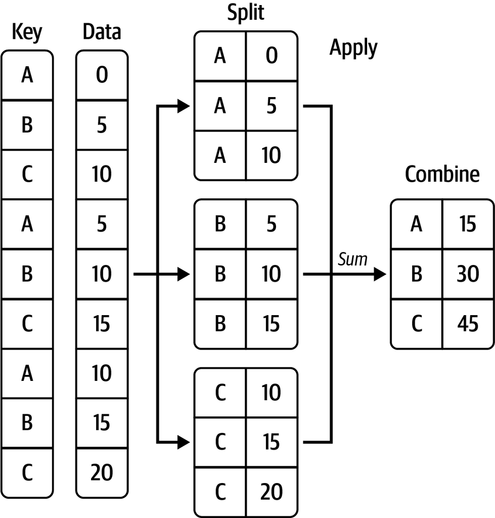

### Grouping Keys

- Grouping keys can vary in type:
  1. **Column Names**: Of the DataFrame to be grouped (most common)
  2. **List/Array**: Directly specifying the groups (the length must match with the axis to group)
  3. **Dictionary/Series**: Groups together obs whose index is associated to the same value in the Dictionary/Series
  4. **Index Levels**: Groups together obs with the same value in a given level of a multiindex
  5. **Function**: Groups together obs with the same `function(index)` result

### An Example Dataset to Group

```python
dfGroup = pd.DataFrame({ "key1" : ["a", "a", "a", None, "b", "b", None],
                    "key2" : pd.Series([1, 2, 1, 2, 1, None, 1], dtype="Int64"),
                    "data1" : np.arange(0,7),
                    "data2" : np.arange(10,17)})
print(f"dfGroup is: \n{dfGroup}\n")
```

```
dfGroup is:
   key1  key2  data1  data2
0     a     1      0     10
1     a     2      1     11
2     a     1      2     12
3  None     2      3     13
4     b     1      4     14
5     b  <NA>      5     15
6  None     1      6     16
```

### Grouping using `groupby`

- The `groupby` is the method to group rows in a DataFrame
  - This creates a GroupBy object (think of it as a collection of DataFrames, one for each group)
  - One of the most frequent keys used is a column name
  - E.g., `grouped_oneKey = dfToGroup.groupby("key1")`
  - It's an intermediate step augmenting the data with the group info
- We can then define an aggregation method on the grouped object
  - We might want to calculate group means
    - We can use the `mean` method on the DataFrameGroupBy object
  - `grouped_oneKey.mean()` computes the mean for each group based on the key variable

### An Example Dataset to Group

```python
dfToGroup = pd.DataFrame({ "key1" : ["a", "a", "a", None, "b", "b", None],
                    "key2" : pd.Series([1, 2, 1, 2, 1, None, 1], dtype="Int64"),
                    "data1" : np.arange(0,7),
                    "data2" : np.arange(10,17)})
print(f"dfToGroup is: \n{dfToGroup}\n")
```

```
dfToGroup is:
   key1  key2  data1  data2
0     a     1      0     10
1     a     2      1     11
2     a     1      2     12
3  None     2      3     13
4     b     1      4     14
5     b  <NA>      5     15
6  None     1      6     16
```

### Grouping - Using a Column Name as Key

```python
dfGrouped_oneKey = dfToGroup.groupby("key1")
print(f"The object dfGrouped_oneKey, defined as dfGroup.groupby('key1') is: {dfGrouped_oneKey}\n")
print(f"The command dfGrouped_oneKey.mean() returns: \n{dfGrouped_oneKey.mean()}\n")
```

```
The object dfGrouped_oneKey, defined as dfGroup.groupby('key1') is: <pandas.core.groupby.generic.DataFrameGroupBy object at 0x12eec6a90>

The command dfGrouped_oneKey.mean() returns:
          key2  data1  data2
key1
a     1.333333    1.0   11.0
b          1.0    4.5   14.5
```

### Iterating over Groups - Understanding the GroupBy object

- The GroupBy object is a collection of DataFrames, one for each group
- If you use it as an iterable it returns a tuple with:
  - The group key
  - The group DataFrame
- Great for exploring the data and debugging (and understanding the groupby operation)

### Iterating over Groups - Understanding the GroupBy object

```python
for name, group in dfGrouped_oneKey:
    print(f"Group name: {name}")
    print(f"Group dataFrame:\n{group}\n")
```

```
Group name: a
Group dataFrame:
  key1  key2  data1  data2
0    a     1      0     10
1    a     2      1     11
2    a     1      2     12

Group name: b
Group dataFrame:
  key1  key2  data1  data2
4    b     1      4     14
5    b  <NA>      5     15
```

- The dataFrame has been split into two groups based on the values of the key variable
- Each column of each group is aggregated using the `mean` method
- The result is a dataFrame with the mean of each column for each group

### Grouping - Using Multiple Column Names as Key

```python
dfGrouped_twoKeys = dfToGroup.groupby(['key1', 'key2'])
print(f"The object dfGrouped_twoKeys, defined as dfToGroup.groupby(['key1', 'key2']) is: {dfGrouped_twoKeys}\n")
print(f"The command dfGrouped_twoKeys.mean() returns: \n{dfGrouped_twoKeys.mean()}\n")
```

```
The object dfGrouped_twoKeys, defined as dfToGroup.groupby(['key1', 'key2']) is: <pandas.core.groupby.generic.DataFrameGroupBy object at 0x12eed8590>

The command dfGrouped_twoKeys.mean() returns:
           data1  data2
key1 key2
a    1       1.0   11.0
     2       1.0   11.0
b    1       4.0   14.0
```

- Grouping by two or more keys creates groups based on all the combinations of their values
  - Hierarchical indexing

### Grouping - Using arrays/Lists as Key

```python
key_states = np.array(["OH", "CA", "CA", "OH", "OH", "CA", "OH"])
key_years = [2005, 2005, 2006, 2005, 2006, 2005, 2006]
print(f"The array 'key_states' and the List 'years' are:\n{key_states}\n{key_years}\n")
dfGrouped_twoKeys_al = dfToGroup.groupby([key_states, key_years])
print(f"These objects can be used as keys on dfToGroup using grouped_twoKeys_al = dfToGroup.groupby([key_states, key_years])\n")
print(f"The command grouped_twoKeys_al.mean(numeric_only=True) returns:\n{dfGrouped_twoKeys_al.mean(numeric_only=True)}\n")
```

```
The array 'key_states' and the List 'years' are:
['OH' 'CA' 'CA' 'OH' 'OH' 'CA' 'OH']
[2005, 2005, 2006, 2005, 2006, 2005, 2006]

These objects can be used as keys on dfToGroup using grouped_twoKeys_al = dfToGroup.groupby([key_states, key_years])

The command grouped_twoKeys_al.mean(numeric_only=True) returns:
         key2  data1  data2
CA 2005   2.0    3.0   13.0
   2006   1.0    2.0   12.0
OH 2005   1.5    1.5   11.5
   2006   1.0    5.0   15.0
```

- Notice that we added the option `numeric_only=True` to avoid errors for computing the mean of the non-numeric column 'key1'

### Grouping - Using Series/Dictionaries as Key

- Using a Series/Dictionary as key maps the index of the DataFrame to the associated value

```python
key_plants = pd.Series(["Plant A", "Plant A", "Plant B", "Plant B", "Plant C", "Plant C", "Plant C"], index=[0, 1, 2, 3, 4, 5, 6])
print(f"The plants series is: \n{key_plants}\n")
print(f"Remember that dfToGroup is: \n{dfToGroup}\n")
```

```
The plants series is:
0    Plant A
1    Plant A
2    Plant B
3    Plant B
4    Plant C
5    Plant C
6    Plant C
dtype: object

Remember that dfToGroup is:
   key1  key2  data1  data2
0     a     1      0     10
1     a     2      1     11
2     a     1      2     12
3  None     2      3     13
4     b     1      4     14
5     b  <NA>      5     15
6  None     1      6     16
```

### Grouping - Using Series/Dictionaries as Key

```python
dfGrouped_oneKey_s = dfToGroup.groupby(key_plants)
print(f"The series 'plant' can be used to group the dfToGroup using dfGrouped_oneKey_s = dfToGroup.groupby(key_plants)\n")
print(f"The command dfGrouped_oneKey_s.mean(numeric_only=True) returns:\n{dfGrouped_oneKey_s.mean(numeric_only=True)}")
```

```
The series 'plant' can be used to group the dfToGroup using dfGrouped_oneKey_s = dfToGroup.groupby(key_plants)

The command dfGrouped_oneKey_s.mean(numeric_only=True) returns:
         key2  data1  data2
Plant A   1.5    0.5   10.5
Plant B   1.5    2.5   12.5
Plant C   1.0    5.0   15.0
```

### Grouping - Using Index Levels

- Gouping can be done based on the levels of a MultiIndex
  - This is done by specifying the level number or name
  - E.g., `df.groupby(level="level_name")`

### Grouping - Using Index Levels

```python
print(f"df2 is: \n{df2}\n")
df2_multiID = df2.set_index(["state", "year"])
print(f""" The command
df2_multiID = df2.set_index(["state", "year"])
creates df2_multiID, a modified df2 with multiindex ["state", "year"]: \n{df2_multiID}\n""")
```

```
df2 is:
   year   state      pop          debt  income  debt_to_income
a  2000    Ohio  1500000  1.200000e+09     NaN             NaN
b  2001    Ohio  1700000  1.500000e+09  2000.0   750000.000000
c  2002    Ohio  3600000  1.700000e+09     NaN             NaN
d  2001  Nevada  2400000  5.000000e+08  3000.0   166666.666667
e  2002  Nevada  2900000  8.000000e+08     NaN             NaN
f  2003  Nevada  3200000  1.000000e+09  4000.0   250000.000000

 The command
df2_multiID = df2.set_index(["state", "year"])
creates df2_multiID, a modified df2 with multiindex ["state", "year"]:
                 pop          debt  income  debt_to_income
state  year
Ohio   2000  1500000  1.200000e+09     NaN             NaN
       2001  1700000  1.500000e+09  2000.0   750000.000000
       2002  3600000  1.700000e+09     NaN             NaN
Nevada 2001  2400000  5.000000e+08  3000.0   166666.666667
       2002  2900000  8.000000e+08     NaN             NaN
       2003  3200000  1.000000e+09  4000.0   250000.000000
```

### Grouping - Using Index Levels

```python
print(f"df2_multiID is: \n{df2_multiID}\n")
print(f""" The command
df2_multiID.groupby(level="state").count()
counts the number of not-NaN values in each column for each state: \n{df2_multiID.groupby(level="state").count()}\n""")
```

```
df2_multiID is:
                 pop          debt  income  debt_to_income
state  year
Ohio   2000  1500000  1.200000e+09     NaN             NaN
       2001  1700000  1.500000e+09  2000.0   750000.000000
       2002  3600000  1.700000e+09     NaN             NaN
Nevada 2001  2400000  5.000000e+08  3000.0   166666.666667
       2002  2900000  8.000000e+08     NaN             NaN
       2003  3200000  1.000000e+09  4000.0   250000.000000

 The command
df2_multiID.groupby(level="state").count()
counts the number of not-NaN values in each column for each state:
        pop  debt  income  debt_to_income
state
Nevada    3     3       2               2
Ohio      3     3       1               1
```

### Grouping - Using Index Levels

```python
print(f"df2_multiID is: \n{df2_multiID}\n")
print(f""" The command
df2_multiID.groupby(level="year").count()
counts the number of not-NaN values in each column for each year: \n{df2_multiID.groupby(level="year").count()}\n""")
```

```
df2_multiID is:
                 pop          debt  income  debt_to_income
state  year
Ohio   2000  1500000  1.200000e+09     NaN             NaN
       2001  1700000  1.500000e+09  2000.0   750000.000000
       2002  3600000  1.700000e+09     NaN             NaN
Nevada 2001  2400000  5.000000e+08  3000.0   166666.666667
       2002  2900000  8.000000e+08     NaN             NaN
       2003  3200000  1.000000e+09  4000.0   250000.000000

 The command
df2_multiID.groupby(level="year").count()
counts the number of not-NaN values in each column for each year:
      pop  debt  income  debt_to_income
year
2000    1     1       0               0
2001    2     2       2               2
2002    2     2       0               0
2003    1     1       1               1
```

### Grouping - Apply the Function `length` on the Index to Define the Key

Let's say that we want to group the data by the length of index names of the following dataset

```python
dfToGroupFun = pd.DataFrame(np.arange(25).reshape([5, 5]), columns=["a", "b", "c", "d", "e"],\
                         index=["Joe", "Jill", "Trey", "Steve", "Wanda"])
print(f"The dfToGroupFun DataFrame is: \n{dfToGroupFun}\n")
```

```
The dfToGroupFun DataFrame is:
        a   b   c   d   e
Joe     0   1   2   3   4
Jill    5   6   7   8   9
Trey   10  11  12  13  14
Steve  15  16  17  18  19
Wanda  20  21  22  23  24
```

### Grouping - Apply the Function `length` on the Index to Define the Key

- Using `dfToGroupFun.groupby(len)` will compute the length of the names of the index create (three) datasets with the resulting groups
- By specifying `sum` in the aggregation, the resulting DataFrame will have the sum of each column for each group stacked vertically

```python
print(f"""The command
dfToGroupFun.groupby(len).sum()
groups by the length of the index labels and performs the sum across the rows of the resulting grouped dataFrames:\n{dfToGroupFun.groupby(len).sum()}\n""")
```

```
The command
dfToGroupFun.groupby(len).sum()
groups by the length of the index labels and performs the sum across the rows of the resulting grouped dataFrames:
    a   b   c   d   e
3   0   1   2   3   4
4  15  17  19  21  23
5  35  37  39  41  43
```

### Grouping - Apply a Lambda Function on a Column to Define the Key

- In some cases it is useful to group on a function of the value of a column
- Let's consider the familiar df2 DataFrame
  - We will group observations by brackets of popoulation size

```python
print(f"df2 is:\n{df2}")
```

```
df2 is:
   year   state      pop          debt  income  debt_to_income
a  2000    Ohio  1500000  1.200000e+09     NaN             NaN
b  2001    Ohio  1700000  1.500000e+09  2000.0   750000.000000
c  2002    Ohio  3600000  1.700000e+09     NaN             NaN
d  2001  Nevada  2400000  5.000000e+08  3000.0   166666.666667
e  2002  Nevada  2900000  8.000000e+08     NaN             NaN
f  2003  Nevada  3200000  1.000000e+09  4000.0   250000.000000
```

### Grouping - Apply a Lambda Function on a Column to Define the Key

```python
print(f"""The command
df2['pop'].apply(lambda x: 'Big Pop' if x > 2000000 else 'Small Pop')
returns the series:\n{df2['pop'].apply(lambda x: 'Big Pop' if x > 2000000 else 'Small Pop')}""")
```

```
The command
df2['pop'].apply(lambda x: 'Big Pop' if x > 2000000 else 'Small Pop')
returns the series:
a    Small Pop
b    Small Pop
c      Big Pop
d      Big Pop
e      Big Pop
f      Big Pop
Name: pop, dtype: object
```

### Grouping - Using Functions to Define Key

- Python functions offer the most flexible method for defining group
- These functions are executed on each index value by default
  - Can also be applied to the values of a column
- The function's return values determine the group names

### Grouping - Use the Output of a Lambda Function to Group and Aggregate

- We can then use the series to group the dataset
- Finally we run the aggregating function sum on the grouped object

```python
print(f"""We can use this series to compute an aggregate function on the columns 'debt' and 'income' by running:
df2[['debt', 'income']].groupby(df2['pop'].apply(lambda x: 'Big Pop' if x > 2000000 else 'Small Pop')).sum():\n{df2[['debt', 'income']].groupby(df2['pop'].apply(lambda x: 'Big Pop' if x > 2000000 else 'Small Pop')).sum()}""")
```

```
We can use this series to compute an aggregate function on the columns 'debt' and 'income' by running:
df2[['debt', 'income']].groupby(df2['pop'].apply(lambda x: 'Big Pop' if x > 2000000 else 'Small Pop')).sum():
                   debt  income
pop
Big Pop    4.000000e+09  7000.0
Small Pop  2.700000e+09  2000.0
```

1. The command `df2['pop'].apply(lambda x: 'Big Pop' if x > 2000000 else 'Small Pop')` returns a series
   - The index is the same as the DataFrame, the values is 'Big Pop'/'Small Pop' depending on 'pop'
2. The series is used to **group the subset DataFrame** (`['debt', 'income']` )
3. `sum` the values of observations belonging to the **grouped subset DataFrame**

### Data Aggregation in Pandas

- Aggregations are transformations yielding scalar values
  - They reduce the dimensionality of the data
  - Common aggregations include `mean`, `count`, `min`, `sum`
  - Pandas optimizes these operations for efficiency
- Aggregations can be applied to a GroupBy object
  - Not limited to predefined methods/functions
    - Custom aggregation functions can be applied
    - Use `.aggregate()` or `.agg()` with custom functions

### Some Aggregation Functions in Pandas

| Function name | Description |
| --- | --- |
| any, all | Return True if any (one or more values) or all non-NA values are True |
| count | Number of non-NA values |
| first, last | First and last non-NA values |
| mean | Mean of non-NA values |
| median | Arithmetic median of non-NA values |
| min, max | Minimum and maximum of non-NA values |
| nth | Retrieve value that would appear at position n with the data in sorted order |
| ohlc | Compute four "open-high-low-close" statistics for time series-like data |
| prod | Product of non-NA values |
| quantile | Compute sample quantile |
| rank | Ordinal ranks of non-NA values, like calling Series.rank |
| size | Compute group sizes, returning result as a Series |
| sum | Sum of non-NA values |
| std, var | Sample standard deviation and variance |

### Data Aggregation in Pandas - Some Examples

```python
print(f"dfGrouped_oneKey.size() returns the number of elements in each group: \n{dfGrouped_oneKey.size()}\n")
print(f"dfGrouped_oneKey.first() returns the first element of each sorted group: \n{dfGrouped_oneKey.first()}\n")
```

```
dfGrouped_oneKey.size() returns the number of elements in each group:
key1
a    3
b    2
dtype: int64

dfGrouped_oneKey.first() returns the first element of each sorted group:
      key2  data1  data2
key1
a        1      0     10
b        1      4     14
```

### Data Aggregation in Pandas - Using Custom Functions

```python
def range_func(x):
    return x.max() - x.min()
print(f"dfToGroup is: \n{dfToGroup}\n")
print(f"dfGrouped_oneKey.agg(range_func) returns: \n{dfGrouped_oneKey.agg(range_func)}\n")
print(f"Lambda functions also work dfGrouped_oneKey.agg(lambda x: x.max() - x.min()) returns: \n{dfGrouped_oneKey.agg(lambda x: x.max() - x.min())}\n")
```

```
dfToGroup is:
   key1  key2  data1  data2
0     a     1      0     10
1     a     2      1     11
2     a     1      2     12
3  None     2      3     13
4     b     1      4     14
5     b  <NA>      5     15
6  None     1      6     16

dfGrouped_oneKey.agg(range_func) returns:
      key2  data1  data2
key1
a        1      2      2
b        0      1      1

Lambda functions also work dfGrouped_oneKey.agg(lambda x: x.max() - x.min()) returns:
      key2  data1  data2
key1
a        1      2      2
b        0      1      1
```

### Using Multiple/Different Functions on Different Columns

- Multiple functions can be applied at once to different columns
  - Use a list specifying the functions
- If the functions that you want to apply are different for each column
  - Use a dictionary with the column names as keys and the functions to apply as values

### Using Multiple/Different Functions on Different Columns

```python
print(f"dfGrouped_oneKey.agg(['mean', 'median']) returns: \n{dfGrouped_oneKey.agg(['mean', 'median'])}\n")
dict_col_fun = {"data1" : ["mean", "median"], "data2" : range_func}
print(f"The column:functions dictionary dict_col_fun is: \n{dict_col_fun}\n")
print(f"dfGrouped_oneKey.agg(dict_col_fun) returns: \n{dfGrouped_oneKey.agg(dict_col_fun)}\n")
```

```
dfGrouped_oneKey.agg(['mean', 'median']) returns:
          key2        data1        data2
          mean median  mean median  mean median
key1
a     1.333333    1.0   1.0    1.0  11.0   11.0
b          1.0    1.0   4.5    4.5  14.5   14.5

The column:functions dictionary dict_col_fun is:
{'data1': ['mean', 'median'], 'data2': <function range_func at 0x12ee7dd00>}

dfGrouped_oneKey.agg(dict_col_fun) returns:
     data1             data2
      mean median range_func
key1
a      1.0    1.0          2
b      4.5    4.5          1
```

### Data Aggregation in Pandas - `apply` Always The Most Flexible Option

- As we saw, `map` is a faster but limited version of apply on non-grouped data
  - The `aggregate` method is the fast but limited apply for grouped data
    - It is intended for scalar output
- The `apply` method is always the most flexible option
  - It can take any function returning a Pandas object (DataFrame or Series) or a scalar
  - Applies to all the groups
  - It will then attempt to combine the pieces
- Use `apply` when:
  - The output of the transformation is a DataFrame or Series
  - The transformation needs the data from multiple columns
  - The transformation needs additional parameters (other than the column data)

### Data Aggregation Using `apply` - An Example

- We will now see a example of using `apply` to perform a group operation in a slightly less "toy" setting
- We will use the dataset "tips" (it comes with the seaborn library but we use a modified version)
  - Our aim is to uncover some features of the distribution of tips
  - We want to identify the highest n top and bottom tips in percentage by groups based on `day`/`time` combination

### Data Aggregation Using `apply` - The Steps of the Example

1. Data Import
2. Definition of a function `compute_pctTip_topBot`
   1. Computes the tip percentage of a bill
   2. Select the highest n top and bottom tips in percentage
3. Application of the function by groups based on `day`/`time` combination
4. Refinements to improve readability (**CRUCIAL**!) of the table result
5. Saving the result to a file

### Importing the `tips` Dataset

```python
import os
#reads the file tips.csv and stores it into a df
tips = pd.read_csv('data/tips.csv')
print(f"Using pd.read_csv('data/tips.csv') to read tips.csv and store the data in the variable tips:")
tips
```

```
Using pd.read_csv('data/tips.csv') to read tips.csv and store the data in the variable tips:
```

|  | total_bill | tip | sex | smoker | day | time | size |
| --- | --- | --- | --- | --- | --- | --- | --- |
| 0 | 16.99 | 1.01 | Female | No | Sun | Dinner | 2 |
| 1 | 10.34 | 1.66 | Male | No | Sun | Dinner | 3 |
| 2 | 21.01 | 3.50 | Male | No | Sun | Dinner | 3 |
| 3 | 23.68 | 3.31 | Male | No | Sun | Dinner | 2 |
| 4 | 24.59 | 3.61 | Female | No | Sun | Dinner | 4 |
| ... | ... | ... | ... | ... | ... | ... | ... |
| 239 | 29.03 | 5.92 | Male | No | Sat | Dinner | 3 |
| 240 | 27.18 | 2.00 | Female | Yes | Sat | Dinner | 2 |
| 241 | 22.67 | 2.00 | Male | Yes | Sat | Dinner | 2 |
| 242 | 17.82 | 1.75 | Male | No | Sat | Dinner | 2 |
| 243 | 18.78 | 3.00 | Female | No | Thur | Dinner | 2 |

244 rows × 7 columns

### Some Info on the `tips` Dataset

The dataset `tips` contains information about tips in a restaurant:

- `total_bill`: Total bill (cost of the meal), including tax, in US dollars
- `tip`: Tip amount in US dollars
- `sex`: Gender of the person attending the table
- `smoker`: Indicates whether the table was in the smoking area or not
- `day`: Day of the week
- `time`: Meal (e.g., Lunch, Dinner)
- `size`: Number of people in the party

### Grouping by `day`/`time` Combination

- The dataset provides the keys that we need for grouping in the columns `day` and `time`
- We need to define the function to apply to each group and extract the information that we need

### Function Definition - `compute_pctTip_topBot`

```python
# Defining the function compute_ratio_topBottom
def compute_pctTip_topBot(group, n):
    # Calculate the percentage of tip from the total bill and add it as a new column 'pctTip'
    group['pctTip'] = 100 * group['tip'] / group['total_bill']
    # Select the top n rows with the highest 'pctTip' values
    top_n = group.nlargest(n, 'pctTip')
    # Select the bottom n rows with the lowest 'pctTip' values
    bottom_n = group.nsmallest(n, 'pctTip')
    # Concatenate the top and bottom rows into a single DataFrame
    #more on this soon, concatenate stacks the two dataframes one on top of the other
    result = pd.concat([top_n, bottom_n])
    # Return the combined DataFrame
    return result
```

### Apply the Function `compute_pctTip_topBot` by `day`/`time` Groups

```python
# Grouping the 'tips' DataFrame by 'day' and 'time', and applying the function to each group
tips.groupby(['day', 'time']).apply(compute_pctTip_topBot, n=2)
```

| day | time |  | total_bill | tip | sex | smoker | day | time | size | pctTip |
| --- | --- | --- | --- | --- | --- | --- | --- | --- | --- | --- |
| Fri | Dinner | 93 | 16.32 | 4.30 | Female | Yes | Fri | Dinner | 2 | 26.348039 |
|  |  | 100 | 11.35 | 2.50 | Female | Yes | Fri | Dinner | 2 | 22.026432 |
|  |  | 90 | 28.97 | 3.00 | Male | Yes | Fri | Dinner | 2 | 10.355540 |
|  |  | 95 | 40.17 | 4.73 | Male | Yes | Fri | Dinner | 4 | 11.774956 |
|  | Lunch | 221 | 13.42 | 3.48 | Female | Yes | Fri | Lunch | 2 | 25.931446 |
|  |  | 222 | 8.58 | 1.92 | Male | Yes | Fri | Lunch | 1 | 22.377622 |
|  |  | 224 | 13.42 | 1.58 | Male | Yes | Fri | Lunch | 2 | 11.773472 |
|  |  | 225 | 16.27 | 2.50 | Female | Yes | Fri | Lunch | 2 | 15.365704 |
| Sat | Dinner | 67 | 3.07 | 1.00 | Female | Yes | Sat | Dinner | 1 | 32.573290 |
|  |  | 232 | 11.61 | 3.39 | Male | No | Sat | Dinner | 2 | 29.198966 |
|  |  | 237 | 32.83 | 1.17 | Male | Yes | Sat | Dinner | 2 | 3.563814 |
|  |  | 102 | 44.30 | 2.50 | Female | Yes | Sat | Dinner | 3 | 5.643341 |
| Sun | Dinner | 172 | 7.25 | 5.15 | Male | Yes | Sun | Dinner | 2 | 71.034483 |
|  |  | 178 | 9.60 | 4.00 | Female | Yes | Sun | Dinner | 2 | 41.666667 |
|  |  | 0 | 16.99 | 1.01 | Female | No | Sun | Dinner | 2 | 5.944673 |
|  |  | 187 | 30.46 | 2.00 | Male | Yes | Sun | Dinner | 5 | 6.565988 |
| Thur | Dinner | 243 | 18.78 | 3.00 | Female | No | Thur | Dinner | 2 | 15.974441 |
|  |  | 243 | 18.78 | 3.00 | Female | No | Thur | Dinner | 2 | 15.974441 |
|  | Lunch | 149 | 7.51 | 2.00 | Male | No | Thur | Lunch | 2 | 26.631158 |
|  |  | 194 | 16.58 | 4.00 | Male | Yes | Thur | Lunch | 2 | 24.125452 |
|  |  | 146 | 18.64 | 1.36 | Female | No | Thur | Lunch | 3 | 7.296137 |
|  |  | 130 | 19.08 | 1.50 | Male | No | Thur | Lunch | 2 | 7.861635 |

### Refinements to the Table to Improve Readability

```python
# Map the weekday names to their corresponding numerical values
weekday_map = {'Mon': 1, 'Tue': 2, 'Wed': 3, 'Thur': 4, 'Fri': 5, 'Sat': 6, 'Sun': 7}
# Map the meal times (e.g., 'Lunch', 'Dinner') to numerical values for sorting
time_map = {'Lunch': 1, 'Dinner': 2}
# Apply the weekday mapping to the 'day' column, creating a new column 'day_order'
tips['day_order'] = tips['day'].map(weekday_map)
# Apply the time mapping to the 'time' column, creating a new column 'time_order'
tips['time_order'] = tips['time'].map(time_map)
tips
```

|  | total_bill | tip | sex | smoker | day | time | size | day_order | time_order |
| --- | --- | --- | --- | --- | --- | --- | --- | --- | --- |
| 0 | 16.99 | 1.01 | Female | No | Sun | Dinner | 2 | 7 | 2 |
| 1 | 10.34 | 1.66 | Male | No | Sun | Dinner | 3 | 7 | 2 |
| 2 | 21.01 | 3.50 | Male | No | Sun | Dinner | 3 | 7 | 2 |
| 3 | 23.68 | 3.31 | Male | No | Sun | Dinner | 2 | 7 | 2 |
| 4 | 24.59 | 3.61 | Female | No | Sun | Dinner | 4 | 7 | 2 |
| ... | ... | ... | ... | ... | ... | ... | ... | ... | ... |
| 239 | 29.03 | 5.92 | Male | No | Sat | Dinner | 3 | 6 | 2 |
| 240 | 27.18 | 2.00 | Female | Yes | Sat | Dinner | 2 | 6 | 2 |
| 241 | 22.67 | 2.00 | Male | Yes | Sat | Dinner | 2 | 6 | 2 |
| 242 | 17.82 | 1.75 | Male | No | Sat | Dinner | 2 | 6 | 2 |
| 243 | 18.78 | 3.00 | Female | No | Thur | Dinner | 2 | 4 | 2 |

244 rows × 9 columns

### Refinements to the Table to Improve Readability

```python
# Group the DataFrame by 'day' and 'time', apply the compute_ratio_topBottom function to each group
# Sort the resulting DataFrame by 'day_order' and 'time_order'
df_pctTip_topBot_by_dayTime = tips.groupby(['day', 'time']).apply(compute_pctTip_topBot, n=2)\
                  .sort_values(['day_order', 'time_order'])
df_pctTip_topBot_by_dayTime
```

| day | time |  | total_bill | tip | sex | smoker | day | time | size | day_order | time_order | pctTip |
| --- | --- | --- | --- | --- | --- | --- | --- | --- | --- | --- | --- | --- |
| Thur | Lunch | 149 | 7.51 | 2.00 | Male | No | Thur | Lunch | 2 | 4 | 1 | 26.631158 |
|  |  | 194 | 16.58 | 4.00 | Male | Yes | Thur | Lunch | 2 | 4 | 1 | 24.125452 |
|  |  | 146 | 18.64 | 1.36 | Female | No | Thur | Lunch | 3 | 4 | 1 | 7.296137 |
|  |  | 130 | 19.08 | 1.50 | Male | No | Thur | Lunch | 2 | 4 | 1 | 7.861635 |
|  | Dinner | 243 | 18.78 | 3.00 | Female | No | Thur | Dinner | 2 | 4 | 2 | 15.974441 |
|  |  | 243 | 18.78 | 3.00 | Female | No | Thur | Dinner | 2 | 4 | 2 | 15.974441 |
| Fri | Lunch | 221 | 13.42 | 3.48 | Female | Yes | Fri | Lunch | 2 | 5 | 1 | 25.931446 |
|  |  | 222 | 8.58 | 1.92 | Male | Yes | Fri | Lunch | 1 | 5 | 1 | 22.377622 |
|  |  | 224 | 13.42 | 1.58 | Male | Yes | Fri | Lunch | 2 | 5 | 1 | 11.773472 |
|  |  | 225 | 16.27 | 2.50 | Female | Yes | Fri | Lunch | 2 | 5 | 1 | 15.365704 |
|  | Dinner | 93 | 16.32 | 4.30 | Female | Yes | Fri | Dinner | 2 | 5 | 2 | 26.348039 |
|  |  | 100 | 11.35 | 2.50 | Female | Yes | Fri | Dinner | 2 | 5 | 2 | 22.026432 |
|  |  | 90 | 28.97 | 3.00 | Male | Yes | Fri | Dinner | 2 | 5 | 2 | 10.355540 |
|  |  | 95 | 40.17 | 4.73 | Male | Yes | Fri | Dinner | 4 | 5 | 2 | 11.774956 |
| Sat | Dinner | 67 | 3.07 | 1.00 | Female | Yes | Sat | Dinner | 1 | 6 | 2 | 32.573290 |
|  |  | 232 | 11.61 | 3.39 | Male | No | Sat | Dinner | 2 | 6 | 2 | 29.198966 |
|  |  | 237 | 32.83 | 1.17 | Male | Yes | Sat | Dinner | 2 | 6 | 2 | 3.563814 |
|  |  | 102 | 44.30 | 2.50 | Female | Yes | Sat | Dinner | 3 | 6 | 2 | 5.643341 |
| Sun | Dinner | 172 | 7.25 | 5.15 | Male | Yes | Sun | Dinner | 2 | 7 | 2 | 71.034483 |
|  |  | 178 | 9.60 | 4.00 | Female | Yes | Sun | Dinner | 2 | 7 | 2 | 41.666667 |
|  |  | 0 | 16.99 | 1.01 | Female | No | Sun | Dinner | 2 | 7 | 2 | 5.944673 |
|  |  | 187 | 30.46 | 2.00 | Male | Yes | Sun | Dinner | 5 | 7 | 2 | 6.565988 |

### Refinements to the Table to Improve Readability

```python
# Group the DataFrame by 'day' and 'time', apply the compute_ratio_topBottom function to each group
# Sort the resulting DataFrame by 'day_order' and 'time_order'
# Drop the columns 'day', 'day_order', 'time', and 'time_order' from the final result
df_pctTip_topBot_by_dayTime = df_pctTip_topBot_by_dayTime.drop(columns=["day", "day_order", "time", "time_order"])\
                  .reset_index(level=[2], drop=True) #From the MultiIndex result (day/time/row), drop the second level (row)
df_pctTip_topBot_by_dayTime
```

| day | time | total_bill | tip | sex | smoker | size | pctTip |
| --- | --- | --- | --- | --- | --- | --- | --- |
| Thur | Lunch | 7.51 | 2.00 | Male | No | 2 | 26.631158 |
|  | Lunch | 16.58 | 4.00 | Male | Yes | 2 | 24.125452 |
|  | Lunch | 18.64 | 1.36 | Female | No | 3 | 7.296137 |
|  | Lunch | 19.08 | 1.50 | Male | No | 2 | 7.861635 |
|  | Dinner | 18.78 | 3.00 | Female | No | 2 | 15.974441 |
|  | Dinner | 18.78 | 3.00 | Female | No | 2 | 15.974441 |
| Fri | Lunch | 13.42 | 3.48 | Female | Yes | 2 | 25.931446 |
|  | Lunch | 8.58 | 1.92 | Male | Yes | 1 | 22.377622 |
|  | Lunch | 13.42 | 1.58 | Male | Yes | 2 | 11.773472 |
|  | Lunch | 16.27 | 2.50 | Female | Yes | 2 | 15.365704 |
|  | Dinner | 16.32 | 4.30 | Female | Yes | 2 | 26.348039 |
|  | Dinner | 11.35 | 2.50 | Female | Yes | 2 | 22.026432 |
|  | Dinner | 28.97 | 3.00 | Male | Yes | 2 | 10.355540 |
|  | Dinner | 40.17 | 4.73 | Male | Yes | 4 | 11.774956 |
| Sat | Dinner | 3.07 | 1.00 | Female | Yes | 1 | 32.573290 |
|  | Dinner | 11.61 | 3.39 | Male | No | 2 | 29.198966 |
|  | Dinner | 32.83 | 1.17 | Male | Yes | 2 | 3.563814 |
|  | Dinner | 44.30 | 2.50 | Female | Yes | 3 | 5.643341 |
| Sun | Dinner | 7.25 | 5.15 | Male | Yes | 2 | 71.034483 |
|  | Dinner | 9.60 | 4.00 | Female | Yes | 2 | 41.666667 |
|  | Dinner | 16.99 | 1.01 | Female | No | 2 | 5.944673 |
|  | Dinner | 30.46 | 2.00 | Male | Yes | 5 | 6.565988 |

### Refinements to the Table to Improve Readability

```python
# For some day/time combinations, there are less than 4 observations leading to duplicates, we remove them Drop the columns 'day', 'day_order', 'time', and 'time_order' from the final result
df_pctTip_topBot_by_dayTime = df_pctTip_topBot_by_dayTime.drop_duplicates()
df_pctTip_topBot_by_dayTime
```

| day | time | total_bill | tip | sex | smoker | size | pctTip |
| --- | --- | --- | --- | --- | --- | --- | --- |
| Thur | Lunch | 7.51 | 2.00 | Male | No | 2 | 26.631158 |
|  | Lunch | 16.58 | 4.00 | Male | Yes | 2 | 24.125452 |
|  | Lunch | 18.64 | 1.36 | Female | No | 3 | 7.296137 |
|  | Lunch | 19.08 | 1.50 | Male | No | 2 | 7.861635 |
|  | Dinner | 18.78 | 3.00 | Female | No | 2 | 15.974441 |
| Fri | Lunch | 13.42 | 3.48 | Female | Yes | 2 | 25.931446 |
|  | Lunch | 8.58 | 1.92 | Male | Yes | 1 | 22.377622 |
|  | Lunch | 13.42 | 1.58 | Male | Yes | 2 | 11.773472 |
|  | Lunch | 16.27 | 2.50 | Female | Yes | 2 | 15.365704 |
|  | Dinner | 16.32 | 4.30 | Female | Yes | 2 | 26.348039 |
|  | Dinner | 11.35 | 2.50 | Female | Yes | 2 | 22.026432 |
|  | Dinner | 28.97 | 3.00 | Male | Yes | 2 | 10.355540 |
|  | Dinner | 40.17 | 4.73 | Male | Yes | 4 | 11.774956 |
| Sat | Dinner | 3.07 | 1.00 | Female | Yes | 1 | 32.573290 |
|  | Dinner | 11.61 | 3.39 | Male | No | 2 | 29.198966 |
|  | Dinner | 32.83 | 1.17 | Male | Yes | 2 | 3.563814 |
|  | Dinner | 44.30 | 2.50 | Female | Yes | 3 | 5.643341 |
| Sun | Dinner | 7.25 | 5.15 | Male | Yes | 2 | 71.034483 |
|  | Dinner | 9.60 | 4.00 | Female | Yes | 2 | 41.666667 |
|  | Dinner | 16.99 | 1.01 | Female | No | 2 | 5.944673 |
|  | Dinner | 30.46 | 2.00 | Male | Yes | 5 | 6.565988 |

### Saving the Table with Results to a File

- Now that we have the table with the results, we can save it to a file
  1. We will save it into markdown using the `to_markdown` method
     - The format used in jupyter notebooks
  2. We will save it to excel using the `to_excel` method,
     - A common format in the corporate world
- Both methods have several options to customize the output
  - Check the help for more details (e.g., `df_pctTip_topBot_by_dayTime.to_excel?`)

```python
# Save the DataFrame to a Markdown file with GitHub-flavored markdown (requires to install the 'tabulate package')
df_pctTip_topBot_by_dayTime.to_markdown(os.path.join('tables', 'df_pctTip_topBot_by_dayTime.md'), tablefmt="github")
# Save the DataFrame to an Excel file with better formatting
df_pctTip_topBot_by_dayTime.to_excel(os.path.join('tables', 'df_pctTip_topBot_by_dayTime.xlsx'), sheet_name='Top_bottom_tips_time_meal')
```

### The Saved Table in Excel

[figure not shown]

## Working with Multiple Data Objects in Pandas

### Index Alignment for Arithmetic Operations

### Arithmetic with Pandas - Automatic Index Alignment

- Pandas simplifies doing operations on multiple objects by accounting for their indexes
- When performing arithmetic operations and other data transformations, Pandas automatically aligns indexes
  - **The resulting index is the union of the indexes of the two Pandas objects**
  - If index pairs don't match, missing values (`NaN`) are introduced

### Arithmetic with Pandas - Automatic Index Alignment in Series

```python
ser3 = pd.Series([7.3, -2.9, 3.4], index=["a", "c", "d"])
ser4 = pd.Series([-2.1, 2.7, -1.5], index=["c", "a", "e",])
print(f"ser3 Series: \n{ser3}\n")
print(f"ser4 Series: \n{ser4}\n")
print(f"Result of ser3 + ser4: \n{ser3 + ser4}")
```

```
ser3 Series:
a    7.3
c   -2.9
d    3.4
dtype: float64

ser4 Series:
c   -2.1
a    2.7
e   -1.5
dtype: float64

Result of ser3 + ser4:
a    10.0
c    -5.0
d     NaN
e     NaN
dtype: float64
```

### Arithmetic with Pandas - Automatic Index Alignment in Series

- `ser3 + ser4` yields a series with indexes `a, c, d, e`
  - Overlapping indexes (`a` and `c`) are matched in the operation
  - Non-overlapping indexes (`d` and `e`) return `NaN`

### Arithmetic with Pandas - Automatic Index Alignment in DataFrames

- The default behavior of Pandas is to **align series indexes with the dataFrame columns**
  - The resulting index is the union of the indexes of the two Pandas objects
  - If index pairs don't match, missing values (`NaN`) are introduced (a union of the indexes)

### Arithmetic with Pandas - Automatic Index Alignment in DataFrames

```python
df4 = pd.DataFrame(np.arange(9.).reshape((3, 3)).transpose(), columns=["Colorado", "Texas", "Ohio"], index=["Colorado", "Texas", "Ohio"])
print(f"DataFrame df4:\n{df4}\n")
ser5 = pd.Series([10, 20, 30], index=["Colorado", "Texas", "Florida"])
print(f"Series ser5:\n{ser5}\n")
print(f"df4 + ser5 aligns the Series index with the DataFrame columns, broadcasting down the rows: \n{df4 + ser5}\n")
```

```
DataFrame df4:
          Colorado  Texas  Ohio
Colorado       0.0    3.0   6.0
Texas          1.0    4.0   7.0
Ohio           2.0    5.0   8.0

Series ser5:
Colorado    10
Texas       20
Florida     30
dtype: int64

df4 + ser5 aligns the Series index with the DataFrame columns, broadcasting down the rows:
          Colorado  Florida  Ohio  Texas
Colorado      10.0      NaN   NaN   23.0
Texas         11.0      NaN   NaN   24.0
Ohio          12.0      NaN   NaN   25.0
```

### Arithmetic with Pandas - Automatic Index Alignment in DataFrames

- With Pandas arithmentic methods (e.g., `add`), use `axis=0` to align with the rows

```python
print(f"DataFrame df4:\n{df4}\n")
print(f"Series ser5:\n{ser5}\n")
print(f"df4.add(ser5, axis=0) aligns the Series index with the DataFrame rows, broadcasting across the columns: \n{df4.add(ser5, axis=0)}\n")
```

```
DataFrame df4:
          Colorado  Texas  Ohio
Colorado       0.0    3.0   6.0
Texas          1.0    4.0   7.0
Ohio           2.0    5.0   8.0

Series ser5:
Colorado    10
Texas       20
Florida     30
dtype: int64

df4.add(ser5, axis=0) aligns the Series index with the DataFrame rows, broadcasting across the columns:
          Colorado  Texas  Ohio
Colorado      10.0   13.0  16.0
Florida        NaN    NaN   NaN
Ohio           NaN    NaN   NaN
Texas         21.0   24.0  27.0
```

### Panda's Arithmetic Methods

| Method | Description |
| --- | --- |
| `add` | Method for addition |
| `sub` | Method for subtraction |
| `div` | Method for division |
| `floordiv` | Method for floor division |
| `mul` | Method for multiplication |
| `mod` | Method for modulo operation |
| `pow` | Method for exponential power |

### 💼 Exercises: Using Index Alignment in Arithmetic Methods

### Exercise 1: Exchange Rate Conversion

You have a DataFrame containing sales data for a multinational company in different countries. There is a column called "Sales Amount (USD)" that represents the sales amount in U.S. dollars. You also have an exchange rate Series that provides the exchange rates for converting the sales amount to the local currency of each country. Create a new column called "Sales Amount (Local Currency)" that converts the sales amount from USD to the local currency using the provided exchange rates.

```
# Sample sales data DataFrame
sales_data = {'Country': ['USA', 'Germany', 'Japan', 'China', 'India'],
              'Sales Amount (USD)': [5000, 3500, 6000, 8000, 4500]}

sales_df = pd.DataFrame(sales_data)

# Sample exchange rate Series
exchange_rates = pd.Series(data=[1.0, 0.85, 110.0, 6.35, 75.0],
                           index=['USA', 'Germany', 'Japan', 'China', 'India'],
                           name='Exchange Rate')

# Create a new column "Sales Amount (Local Currency)" in sales_df by converting USD to local currency
```

### Exercise 2: GDP Growth Rate Calculation

Calculate the annual GDP growth rate for a list of countries. You are provided with two DataFrames: `gdp_last_year` and `gdp_this_year`, each containing the GDP values for various countries in the respective years. Add a new column to `gdp_this_year` DataFrame named "GDP Growth Rate (%)" that calculates the percentage growth rate from the previous year.

```
# GDP data for the last year
gdp_last_year = pd.DataFrame({'Country': ['USA', 'China', 'India', 'Germany', 'Brazil'],
                              'GDP': [21.43, 14.34, 2.87, 3.86, 1.84]})  # Trillions USD

# GDP data for this year
gdp_this_year = pd.DataFrame({'Country': ['USA', 'China', 'India', 'Germany', 'Brazil'],
                              'GDP': [22.32, 15.42, 3.05, 3.95, 1.92]})  # Trillions USD

# Calculate GDP Growth Rate and add as a new column to gdp_this_year DataFrame
```

### Exercise 3: Portfolio Value Recalculation

Given a DataFrame `portfolio` containing the number of shares held in different companies and a Series `stock_prices` representing the current stock prices, calculate the total value of the portfolio for each company and add a new column "Total Value" to the `portfolio` DataFrame.

```
# Sample portfolio data
portfolio = pd.DataFrame({'Company': ['Apple', 'Google', 'Amazon', 'Tesla'],
                          'Shares': [50, 30, 20, 10]})

# Current stock prices
stock_prices = pd.Series(data=[150, 2800, 3300, 700],
                         index=['Apple', 'Google', 'Amazon', 'Tesla'],
                         name='Stock Price')

# Calculate Total Value of shares for each company and add as a new column to portfolio DataFrame
```

### Exercise 4: Inflation Adjustment

Adjust the prices of a list of products over the years for inflation. You are given a DataFrame `product_prices` with columns "Year", "Product", and "Price". You also have a Series `inflation_rate` that provides the annual inflation rate. Create a new column "Adjusted Price" that adjusts the prices for inflation to the current year.

```
# Sample product prices data
product_prices = pd.DataFrame({'Year': [2018, 2019, 2020, 2021, 2022],
                               'Product': ['Laptop', 'Laptop', 'Laptop', 'Laptop', 'Laptop'],
                               'Price': [1000, 1050, 1100, 1150, 1200]})

# Annual inflation rate
inflation_rate = pd.Series(data=[2.4, 1.8, 1.6, 2.2, 3.0],
                           index=[2018, 2019, 2020, 2021, 2022],
                           name='Inflation Rate (%)')

# Adjust product prices for inflation and add as a new column to product_prices DataFrame
```

### Exercise 5: Merging Sales Data with Currency Conversion Rates

Merge two DataFrames: `international_sales` containing sales amounts in USD and `currency_conversion` providing currency conversion rates. After merging, create a new column "Sales in Local Currency" to convert the sales amounts to local currencies.

```
# International sales data in USD
international_sales = pd.DataFrame({'Country': ['USA', 'UK', 'France', 'India', 'Japan'],
                                    'Sales Amount (USD)': [1000, 2000, 1500, 2500, 3000]})

# Currency conversion rates
currency_conversion = pd.DataFrame({'Country': ['USA', 'UK', 'France', 'India', 'Japan'],
                                    'Conversion Rate': [1.0, 0.75, 0.9, 75, 110]})

# Merge DataFrames and convert Sales Amount to local currency
```

### Exercise 6: Stock Market Index Rebalancing

Given a DataFrame `stock_market_index` containing the composition of a stock market index and a Series `new_market_cap` providing the latest market capitalization for each stock, rebalance the index by updating the market capitalizations and calculating the new index weights.

[output not shown]

### Exercise 7: Adjusting Income Data for Cost of Living

You have a DataFrame `income_data` containing average annual household incomes for various cities. Additionally, you are given a Series `cost_of_living_index` that provides the cost of living index for each city. Normally, Pandas aligns the Series index with the DataFrame columns, but you need to override this behavior to align the Series index with the DataFrame rows. This alignment is necessary to adjust the incomes for the cost of living in each city.

#### Task Description

- The DataFrame `income_data` has cities as rows and years as columns.
- The Series `cost_of_living_index` contains a cost of living index for each city.
- Adjust the household incomes in `income_data` by dividing each city's income by its corresponding cost of living index.

#### Sample Data and Code

```
import pandas as pd

# Average annual household income data (in USD)
income_data = pd.DataFrame({'2018': [60000, 80000, 55000],
                            '2019': [62000, 82000, 56000],
                            '2020': [64000, 85000, 58000]},
                           index=['New York', 'San Francisco', 'Detroit'])

# Cost of living index for each city (higher values mean higher cost of living)
cost_of_living_index = pd.Series(data=[240, 280, 180],
                                 index=['New York', 'San Francisco', 'Detroit'],
                                 name='Cost of Living Index')

# Adjust the incomes for cost of living
# Override the default behavior to align the Series index with the DataFrame rows
```

I need you to provide me with code, thoroughly commented, to solve these exercises and display the results. Put all the code in a single python cell and separate the different exercises by printing the current exercise with separators

## Working with Multiple Data Objects in Pandas

### Data Concatenation and Merging

### DataFrame Concatenation

- **Concatenating**: Stacks datasets by axis
  - `concat()`:
    - Stacks rows or binds columns (but for the columns merge is more flexible)
    - It is the method used when combining the result of groupby operations
    - Mostly used to stack rows using `axis=0` and ignoring indexes using `ignore_index=True`

### DataFrame Concatenation in Pandas - `concat()`- `ignore_index=True`

```python
df9 = pd.DataFrame({'A': [1, 2], 'B': [ 3, 4]})
df10 = pd.DataFrame({'A': [5, 6], 'B': [7, 8]})
print(f"df9 is:\n{df9}\n\ndf10 is:\n{df10}\n")
print(f"The command pd.concat([df9, df10], axis=0, ignore_index=True) concatenates df9 and df10 along the rows: \n{pd.concat([df9, df10], axis=0, ignore_index=True)}\n")
```

```
df9 is:
   A  B
0  1  3
1  2  4

df10 is:
   A  B
0  5  7
1  6  8

The command pd.concat([df9, df10], axis=0, ignore_index=True) concatenates df9 and df10 along the rows:
   A  B
0  1  3
1  2  4
2  5  7
3  6  8
```

### DataFrame Concatenation in Pandas - `concat()`

```python
print(f"df9 is:\n{df9}\n\ndf10 is:\n{df10}\n")
print(f"The command pd.concat([df9, df10], axis=0) concatenates df9 and df10 along the rows keeping the index: \n{pd.concat([df9, df10], axis=0)}\n")
```

```
df9 is:
   A  B
0  1  3
1  2  4

df10 is:
   A  B
0  5  7
1  6  8

The command pd.concat([df9, df10], axis=0) concatenates df9 and df10 along the rows keeping the index:
   A  B
0  1  3
1  2  4
0  5  7
1  6  8
```

### DataFrame Concatenation in Pandas - `concat()` - Different Index Names Along Concatenation

```python
df11 = pd.DataFrame({'A': [11, 12], 'B': [13, 14]})
df12 = pd.DataFrame({'C': [15, 16], 'D': [17, 18]})
print(f"df11 is:\n{df11}\n\ndf12 is:\n{df12}\n")
print(f"""The command
pd.concat([df11, df12], axis=0, ignore_index=True) concatenates df11 and df12 (with different column names) along the rows:
{pd.concat([df11, df12], axis=0, ignore_index=True)}\n""")
```

```
df11 is:
    A   B
0  11  13
1  12  14

df12 is:
    C   D
0  15  17
1  16  18

The command
pd.concat([df11, df12], axis=0, ignore_index=True) concatenates df11 and df12 (with different column names) along the rows:
      A     B     C     D
0  11.0  13.0   NaN   NaN
1  12.0  14.0   NaN   NaN
2   NaN   NaN  15.0  17.0
3   NaN   NaN  16.0  18.0
```

### Merging

- **Merging**: Integrates dataframes columns based on ID/key
  - `merge()`is the most flexible function to merge

Syntax

```
pd.merge(df_a, df_b, on='key')
```

- `key` sets the column(s) storing the information identifying the same observations across dataframes

### The Different Kinds of Merge

- Different kinds of merges can be performed using the parameter `how`

| Option | Behavior |
| --- | --- |
| `how="inner"` | The output Dataframe keys are the **intersection** of the keys of both tables |
| `how="left"` | The output Dataframe keys are the ones from the **left** table |
| `how="right"` | The output Dataframe keys are the ones from the **right** table |
| `how="outer"` | The output Dataframe keys are the **union** of the key from both tables |

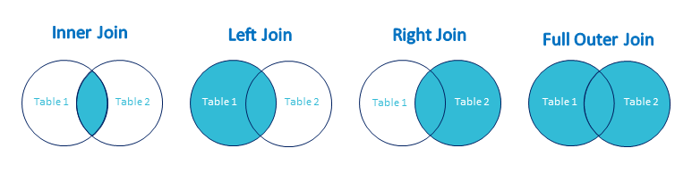

### The Left Merge

- We will focus on the **left merge** that is (allegedly) the most useful in data analysis
  - There is a main dataset (receiver) to augment with info from other datasets (donors)
  - E.g., An education economist investigating the impact of a policy on students' grades works with:
    - The core (receiver) dataset storing info on students' scores
    - Many other (donor) datasets providing info on timing of the policy and covariates
      - Socio-economic status, Age, Extracullicular activities, etc.

### DataFrame Merging - `merge()`

```python
df_WA = pd.DataFrame({'ID': ['jin', 'luca', 'mazhar', 'lynne', 'massimo', 'matthew'],
                        'weight': [60, 70, 66, 50, 65, 60],
                        'age': [11, 12, 12, 13, 12, 12]})
df_HA = pd.DataFrame({ 'ID': ['luca', 'lynne', 'matthew', 'jin', 'massimo', 'mazhar'],
                        'height': [170, 178, 164, np.NAN, 180, 175],
                        'age': [12, 13, 12, 11, 12, 12,]})
print(f"data_WA is: \n{df_WA}\n")
print(f"data_HA is: \n{df_HA}\n")
```

```
data_WA is:
        ID  weight  age
0      jin      60   11
1     luca      70   12
2   mazhar      66   12
3    lynne      50   13
4  massimo      65   12
5  matthew      60   12

data_HA is:
        ID  height  age
0     luca   170.0   12
1    lynne   178.0   13
2  matthew   164.0   12
3      jin     NaN   11
4  massimo   180.0   12
5   mazhar   175.0   12
```

### DataFrame Merging - `merge()`

```python
print(f"pd.merge(df_WA, df_HA, on='ID', how='left') merges df_HA and df_WA on the 'ID' column using a left join: \n{pd.merge(df_WA, df_HA, on='ID', how='left')}\n")
```

```
pd.merge(df_WA, df_HA, on='ID', how='left') merges df_HA and df_WA on the 'ID' column using a left join:
        ID  weight  age_x  height  age_y
0      jin      60     11     NaN     11
1     luca      70     12   170.0     12
2   mazhar      66     12   175.0     12
3    lynne      50     13   178.0     13
4  massimo      65     12   180.0     12
5  matthew      60     12   164.0     12
```

### Join - A Simplified Index-Based Merge

- `join()` is a simplified left-merging based on index labels
  - `df_WA.join(df_HA)` left-joins `df_WA` (receiver) and `df_HA` (donor) on their indexes
  - The parameters `lsuffix` and `rsuffix` add the suffixes to overlapping column names
    - The default suffixes are `_x` and `_y`
- In this case the index do not represent the ID
  - This merge is **CORRUPTING THE INFORMATION IN THE DATA**
  - Any analysis based on this merge will be **WRONG**
  - We are just doing it for illustration purposes

### Understanding DataFrame Merging in Pandas - `join()`

```python
print(f"df_WA.join(df_HA, how='left') joins df_WA and df_HA on the index using a left join: \n{df_WA.join(df_HA, how='left', lsuffix='_dfWA', rsuffix='_dfHA')}\n")
print(f"df_WA.join(df_WA[['data2']], how='left') only adds the column of interest from df_WA: \n{df_WA.join(df_HA[['height']], how='left')}\n")
```

```
df_WA.join(df_HA, how='left') joins df_WA and df_HA on the index using a left join:
   ID_dfWA  weight  age_dfWA  ID_dfHA  height  age_dfHA
0      jin      60        11     luca   170.0        12
1     luca      70        12    lynne   178.0        13
2   mazhar      66        12  matthew   164.0        12
3    lynne      50        13      jin     NaN        11
4  massimo      65        12  massimo   180.0        12
5  matthew      60        12   mazhar   175.0        12

df_WA.join(df_WA[['data2']], how='left') only adds the column of interest from df_WA:
        ID  weight  age  height
0      jin      60   11   170.0
1     luca      70   12   178.0
2   mazhar      66   12   164.0
3    lynne      50   13     NaN
4  massimo      65   12   180.0
5  matthew      60   12   175.0
```

### Strategy for Effective Merging - Check the Calls to Merge

**Key Considerations for Merging DataFrames**:

- **Potential for Errors**:
  - Merging is a delicate process that might lead to data corruption
    - Countless cases of scientific and business analysis invalidated by merging errors
  - A careful and methodical approach is crucial to ensure data integrity
- **Always triple check when merging**
  - **You have just saw what might happen, and no warning nor error is raised**
  - If the AI is doing merges, check them **thoroughly**

### Strategy for Effective Merging - Common Problems

- Often the results of a merge are not what you expect
  - Duplicates keys in one or both dataframes might lead to unexpected results
    - Multiple matches for the same key
  - Subtle differences in keys/ID can lead loss of information
    - Need to be of the same type (9 and "9" are different)
    - There might be small typing differences (e.g., "9" and " 9", "Padova" and "padova", "Nicolò" and "Nicolo'")
    - In these cases the merge will return more NaN that it should

## Data Reshaping

### Different Shapes of Data - Wide and Long

### Different Shapes of Data - Use Cases

- The shape of a given dataset depends on the preferences of the data provider
  - You might find data referring to the same observations in different shapes
  - It is then important to be able to reshape the data to merge them
- Apart from data ingestion, different shapes are more convenient in different tasks
  - Depending on the function you want to perform, you need one shape or the other
- Pandas provides methods to reshape data
  - `stack()` and `unstack()` are the most common ones
  - `pivot()` and `melt()` are more advanced and flexible

### Reshaping in Pandas - Some Resources

- Pandas provides a variety of methods to reshape data
  - `stack()` and `unstack()` are the most common ones
  - `pivot()` and `melt()` are more advanced and flexible
- We won't be able to look at this topic in the course
- Those of you that need this competence, can find excellent resources:
  - [Par 8.3 of Python for Data Analysis](https://wesmckinney.com/book/data-wrangling#prep_reshape)
  - [The whole Ch.8 of Python for Data Analysis](https://wesmckinney.com/book/data-wrangling)
  - [Pandas documentation](https://pandas.pydata.org/pandas-docs/stable/user_guide/reshaping.html)

### Additional Resources on Pandas

[Ch. 5-8 of Python for Data Analysis](https://wesmckinney.com/book/pandas-basics)  
[Ch.3 of Python Data Science Handbook](https://jakevdp.github.io/PythonDataScienceHandbook/03.00-introduction-to-pandas.html)  
[Pandas documentation](http://pandas.pydata.org/pandas-docs/stable/)  
[Pandas quickstart tutorial](https://pandas.pydata.org/pandas-docs/stable/getting_started/index.html)

## Working with Multiple Data Objects in Pandas

### Index Alignment for Arithmetic Operations

### Arithmetic with Pandas - Automatic Index Alignment

- Pandas simplifies doing operations on multiple objects by accounting for their indexes
- When performing arithmetic operations and other data transformations, Pandas automatically aligns indexes
  - **The resulting index is the union of the indexes of the two Pandas objects**
  - If index pairs don't match, missing values (`NaN`) are introduced

### Arithmetic with Pandas - Automatic Index Alignment in Series

```python
ser3 = pd.Series([7.3, -2.9, 3.4], index=["a", "c", "d"])
ser4 = pd.Series([-2.1, 2.7, -1.5], index=["c", "a", "e",])
print(f"ser3 Series: \n{ser3}\n")
print(f"ser4 Series: \n{ser4}\n")
print(f"Result of ser3 + ser4: \n{ser3 + ser4}")
```

```
ser3 Series:
a    7.3
c   -2.9
d    3.4
dtype: float64

ser4 Series:
c   -2.1
a    2.7
e   -1.5
dtype: float64

Result of ser3 + ser4:
a    10.0
c    -5.0
d     NaN
e     NaN
dtype: float64
```

### Arithmetic with Pandas - Automatic Index Alignment in Series

- `ser3 + ser4` yields a series with indexes `a, c, d, e`
  - Overlapping indexes (`a` and `c`) are matched in the operation
  - Non-overlapping indexes (`d` and `e`) return `NaN`

### Arithmetic with Pandas - Automatic Index Alignment in DataFrames

- The default behavior of Pandas is to **align series indexes with the dataFrame columns**
  - The resulting index is the union of the indexes of the two Pandas objects
  - If index pairs don't match, missing values (`NaN`) are introduced (a union of the indexes)

### Arithmetic with Pandas - Automatic Index Alignment in DataFrames

```python
df4 = pd.DataFrame(np.arange(9.).reshape((3, 3)).transpose(), columns=["Colorado", "Texas", "Ohio"], index=["Colorado", "Texas", "Ohio"])
print(f"DataFrame df4:\n{df4}\n")
ser5 = pd.Series([10, 20, 30], index=["Colorado", "Texas", "Florida"])
print(f"Series ser5:\n{ser5}\n")
print(f"df4 + ser5 aligns the Series index with the DataFrame columns, broadcasting down the rows: \n{df4 + ser5}\n")
```

```
DataFrame df4:
          Colorado  Texas  Ohio
Colorado       0.0    3.0   6.0
Texas          1.0    4.0   7.0
Ohio           2.0    5.0   8.0

Series ser5:
Colorado    10
Texas       20
Florida     30
dtype: int64

df4 + ser5 aligns the Series index with the DataFrame columns, broadcasting down the rows:
          Colorado  Florida  Ohio  Texas
Colorado      10.0      NaN   NaN   23.0
Texas         11.0      NaN   NaN   24.0
Ohio          12.0      NaN   NaN   25.0
```

### Arithmetic with Pandas - Automatic Index Alignment in DataFrames

- With Pandas arithmentic methods (e.g., `add`), use `axis=0` to align with the rows

```python
print(f"DataFrame df4:\n{df4}\n")
print(f"Series ser5:\n{ser5}\n")
print(f"df4.add(ser5, axis=0) aligns the Series index with the DataFrame rows, broadcasting across the columns: \n{df4.add(ser5, axis=0)}\n")
```

```
DataFrame df4:
          Colorado  Texas  Ohio
Colorado       0.0    3.0   6.0
Texas          1.0    4.0   7.0
Ohio           2.0    5.0   8.0

Series ser5:
Colorado    10
Texas       20
Florida     30
dtype: int64

df4.add(ser5, axis=0) aligns the Series index with the DataFrame rows, broadcasting across the columns:
          Colorado  Texas  Ohio
Colorado      10.0   13.0  16.0
Florida        NaN    NaN   NaN
Ohio           NaN    NaN   NaN
Texas         21.0   24.0  27.0
```

### Panda's Arithmetic Methods

| Method | Description |
| --- | --- |
| `add` | Method for addition |
| `sub` | Method for subtraction |
| `div` | Method for division |
| `floordiv` | Method for floor division |
| `mul` | Method for multiplication |
| `mod` | Method for modulo operation |
| `pow` | Method for exponential power |

### 💼 Exercises: Using Index Alignment in Arithmetic Methods

### Exercise 1: Exchange Rate Conversion

You have a DataFrame containing sales data for a multinational company in different countries. There is a column called "Sales Amount (USD)" that represents the sales amount in U.S. dollars. You also have an exchange rate Series that provides the exchange rates for converting the sales amount to the local currency of each country. Create a new column called "Sales Amount (Local Currency)" that converts the sales amount from USD to the local currency using the provided exchange rates.

```
# Sample sales data DataFrame
sales_data = {'Country': ['USA', 'Germany', 'Japan', 'China', 'India'],
              'Sales Amount (USD)': [5000, 3500, 6000, 8000, 4500]}

sales_df = pd.DataFrame(sales_data)

# Sample exchange rate Series
exchange_rates = pd.Series(data=[1.0, 0.85, 110.0, 6.35, 75.0],
                           index=['USA', 'Germany', 'Japan', 'China', 'India'],
                           name='Exchange Rate')

# Create a new column "Sales Amount (Local Currency)" in sales_df by converting USD to local currency
```

### Exercise 2: GDP Growth Rate Calculation

Calculate the annual GDP growth rate for a list of countries. You are provided with two DataFrames: `gdp_last_year` and `gdp_this_year`, each containing the GDP values for various countries in the respective years. Add a new column to `gdp_this_year` DataFrame named "GDP Growth Rate (%)" that calculates the percentage growth rate from the previous year.

```
# GDP data for the last year
gdp_last_year = pd.DataFrame({'Country': ['USA', 'China', 'India', 'Germany', 'Brazil'],
                              'GDP': [21.43, 14.34, 2.87, 3.86, 1.84]})  # Trillions USD

# GDP data for this year
gdp_this_year = pd.DataFrame({'Country': ['USA', 'China', 'India', 'Germany', 'Brazil'],
                              'GDP': [22.32, 15.42, 3.05, 3.95, 1.92]})  # Trillions USD

# Calculate GDP Growth Rate and add as a new column to gdp_this_year DataFrame
```

### Exercise 3: Portfolio Value Recalculation

Given a DataFrame `portfolio` containing the number of shares held in different companies and a Series `stock_prices` representing the current stock prices, calculate the total value of the portfolio for each company and add a new column "Total Value" to the `portfolio` DataFrame.

```
# Sample portfolio data
portfolio = pd.DataFrame({'Company': ['Apple', 'Google', 'Amazon', 'Tesla'],
                          'Shares': [50, 30, 20, 10]})

# Current stock prices
stock_prices = pd.Series(data=[150, 2800, 3300, 700],
                         index=['Apple', 'Google', 'Amazon', 'Tesla'],
                         name='Stock Price')

# Calculate Total Value of shares for each company and add as a new column to portfolio DataFrame
```

### Exercise 4: Inflation Adjustment

Adjust the prices of a list of products over the years for inflation. You are given a DataFrame `product_prices` with columns "Year", "Product", and "Price". You also have a Series `inflation_rate` that provides the annual inflation rate. Create a new column "Adjusted Price" that adjusts the prices for inflation to the current year.

```
# Sample product prices data
product_prices = pd.DataFrame({'Year': [2018, 2019, 2020, 2021, 2022],
                               'Product': ['Laptop', 'Laptop', 'Laptop', 'Laptop', 'Laptop'],
                               'Price': [1000, 1050, 1100, 1150, 1200]})

# Annual inflation rate
inflation_rate = pd.Series(data=[2.4, 1.8, 1.6, 2.2, 3.0],
                           index=[2018, 2019, 2020, 2021, 2022],
                           name='Inflation Rate (%)')

# Adjust product prices for inflation and add as a new column to product_prices DataFrame
```

### Exercise 5: Merging Sales Data with Currency Conversion Rates

Merge two DataFrames: `international_sales` containing sales amounts in USD and `currency_conversion` providing currency conversion rates. After merging, create a new column "Sales in Local Currency" to convert the sales amounts to local currencies.

```
# International sales data in USD
international_sales = pd.DataFrame({'Country': ['USA', 'UK', 'France', 'India', 'Japan'],
                                    'Sales Amount (USD)': [1000, 2000, 1500, 2500, 3000]})

# Currency conversion rates
currency_conversion = pd.DataFrame({'Country': ['USA', 'UK', 'France', 'India', 'Japan'],
                                    'Conversion Rate': [1.0, 0.75, 0.9, 75, 110]})

# Merge DataFrames and convert Sales Amount to local currency
```

### Exercise 6: Stock Market Index Rebalancing

Given a DataFrame `stock_market_index` containing the composition of a stock market index and a Series `new_market_cap` providing the latest market capitalization for each stock, rebalance the index by updating the market capitalizations and calculating the new index weights.

[output not shown]

### Exercise 7: Adjusting Income Data for Cost of Living

You have a DataFrame `income_data` containing average annual household incomes for various cities. Additionally, you are given a Series `cost_of_living_index` that provides the cost of living index for each city. Normally, Pandas aligns the Series index with the DataFrame columns, but you need to override this behavior to align the Series index with the DataFrame rows. This alignment is necessary to adjust the incomes for the cost of living in each city.

#### Task Description

- The DataFrame `income_data` has cities as rows and years as columns.
- The Series `cost_of_living_index` contains a cost of living index for each city.
- Adjust the household incomes in `income_data` by dividing each city's income by its corresponding cost of living index.

#### Sample Data and Code

```
import pandas as pd

# Average annual household income data (in USD)
income_data = pd.DataFrame({'2018': [60000, 80000, 55000],
                            '2019': [62000, 82000, 56000],
                            '2020': [64000, 85000, 58000]},
                           index=['New York', 'San Francisco', 'Detroit'])

# Cost of living index for each city (higher values mean higher cost of living)
cost_of_living_index = pd.Series(data=[240, 280, 180],
                                 index=['New York', 'San Francisco', 'Detroit'],
                                 name='Cost of Living Index')

# Adjust the incomes for cost of living
# Override the default behavior to align the Series index with the DataFrame rows
```

I need you to provide me with code, thoroughly commented, to solve these exercises and display the results. Put all the code in a single python cell and separate the different exercises by printing the current exercise with separators

### Merging

### Strategy for Effective Merging - The Checks to Do When Merging

- **Check the keys/ID of each dataset for duplicates**
- **Identify Non-Matching keys/ID Before Merging**:
  - Identify the keys in the receiver dataframe that do not have a match in the donor dataframe
  - For these obs the donated columns will be `NaN` in the merged dataframe
  - Better to use indexes for this check
    - Allows to use the `.index.get_level_values` method
    - For multiindex DataFrames creates automatically the combinations of indexes

### Strategy for Effective Merging - The Checks to Do When Merging

- **Prefer Adding Columns Individually**:
  - Enhances code readability and manageability
  - Adding one column at a time makes it easier track `NaN` values and perform the checks below:
    1. **Check the NaN in the column to be received**
       - The column stored in the donor dataframe
       - If there are `NaN` values they will pass to the receiver dataframe
    2. **Check the NaN in the column received**
       - The column stored in the receiver dataframe (only available after the merge)
       - The number of `NaN` should be equal to the **sum** of:
         - The number of `NaN` in the donor dataframe plus
         - the number of indexes/keys/ID in the receiver not in the donor

### Strategy for Effective Merging - The Datasets

- Let's create two datasets to illustrate the checks to do when merging

```python
df_WAmod = df_WA[df_WA['ID'] != 'luca'].copy()
print(f"The command df_WAmod = df_WAmod[df_WAmod['ID'] != 'luca'].copy() creates a new DataFrame from df_WA by removing the row with ID 'luca':\n{df_WAmod}\n")
df_HAmod = df_HA[df_HA['ID'] != 'lynne'].copy()
print(f"The command df_HAmod = df_HA[df_HA['ID'] != 'lynne'].copy() creates a new DataFrame from df_HA by removing the row with ID 'lynne':\n{df_HAmod}\n")
```

```
The command df_WAmod = df_WAmod[df_WAmod['ID'] != 'luca'].copy() creates a new DataFrame from df_WA by removing the row with ID 'luca':
        ID  weight  age
0      jin      60   11
2   mazhar      66   12
3    lynne      50   13
4  massimo      65   12
5  matthew      60   12

The command df_HAmod = df_HA[df_HA['ID'] != 'lynne'].copy() creates a new DataFrame from df_HA by removing the row with ID 'lynne':
        ID  height  age
0     luca   170.0   12
2  matthew   164.0   12
3      jin     NaN   11
4  massimo   180.0   12
5   mazhar   175.0   12
```

### Strategy for Effective Merging - Reindexing

- Reindexing allows to use the method `.index.get_level_values` to get the keys
  - Not needed in our example with just one column for key
  - Convenient when there are multiple columns for the key

### Strategy for Effective Merging - Reindexing

```python
df_WAmod.set_index('ID', inplace=True)
print(f"The command df_WAmod.set_index('ID', inplace=True) sets the index of df_WAmod to 'ID':\n{df_WAmod}\n")
df_HAmod.set_index('ID', inplace=True)
print(f"The command df_HAmod.set_index('ID', inplace=True) sets the index of df_WAmod to 'ID':\n{df_HAmod}\n")
```

```
The command df_WAmod.set_index('ID', inplace=True) sets the index of df_WAmod to 'ID':
         weight  age
ID
jin          60   11
mazhar       66   12
lynne        50   13
massimo      65   12
matthew      60   12

The command df_HAmod.set_index('ID', inplace=True) sets the index of df_WAmod to 'ID':
         height  age
ID
luca      170.0   12
matthew   164.0   12
jin         NaN   11
massimo   180.0   12
mazhar    175.0   12
```

### Strategy for Effective Merging - Identifying Non-Matching IDs/indexes/keys

- In a MultiIndex, the `get_level_values()` method returns combinations of the index values at the specified level
  - This uniquely identifies each observation
  - Using a column is fine for a single key
  - With multiple IDs/indexes/keys it is better to use a MultiIndex

### Strategy for Effective Merging - Identifying Non-Matching IDs/indexes/keys

```python
idsReceiver_notIn_donor = set(df_WAmod.index.get_level_values('ID')) - set(df_HAmod.index.get_level_values('ID'))
print(f"""The command
idsReceiver_notIn_donor = set(df_WAmod.index.get_level_values('ID')) - set(df_HAmod.index.get_level_values('ID'))
identifies unique IDs in df_WAmod (receiver) but not in df_HAmod (donor):\n
{idsReceiver_notIn_donor}""")
```

```
The command
idsReceiver_notIn_donor = set(df_WAmod.index.get_level_values('ID')) - set(df_HAmod.index.get_level_values('ID'))
identifies unique IDs in df_WAmod (receiver) but not in df_HAmod (donor):

{'lynne'}
```

- This check is in line with our expectations
  - No NaN arising due to typing differences or oddities due to duplicates
- It identifiee the IDs that will result in NaN during the merge
  - These will be added to the ones already in the donor column

### Strategy for Effective Merging - Merge the DataFrame one Column at a Time

- Since we set the key column as index we can directly use `join`

```python
df_WAmodJoined = df_WAmod.join(df_HAmod['height'])
print(f"""The command
df_WAmodJoined = df_WAmod.join(df_HAmod['height'])
adds the column 'height' from df_HAmod (donor) to df_WAmod (receiver) on the index:\n""")
df_WAmodJoined
```

```
The command
df_WAmodJoined = df_WAmod.join(df_HAmod['height'])
adds the column 'height' from df_HAmod (donor) to df_WAmod (receiver) on the index:
```

| ID | weight | age | height |
| --- | --- | --- | --- |
| jin | 60 | 11 | NaN |
| mazhar | 66 | 12 | 175.0 |
| lynne | 50 | 13 | NaN |
| massimo | 65 | 12 | 180.0 |
| matthew | 60 | 12 | 164.0 |

### Strategy for Effective Merging - Compare the NaN Pre/Post Merge

- We want to check the indexes of the NaN in:
  1. The column **to be received** (in the donor DataFrame)
  2. The column **effectively received** after merge (in the receiver DataFrame)

```python
heightNan_idsDonor = set(df_HAmod[df_HAmod['height'].isna()].index.get_level_values('ID'))
print(f"""The command
heightNan_idsDonor = set(df_HAmod[df_HAmod['height'].isna()].index.get_level_values('ID'))
stores the index of the NaN values in the 'height' column of the donor: \n{heightNan_idsDonor}\n""")
heightNan_idsReceived = set(df_WAmodJoined[df_WAmodJoined['height'].isna()].index.get_level_values('ID'))
print(f"""The command
heightNan_idsReceived = set(df_WAmodJoined[df_WAmodJoined['height'].isna()].index.get_level_values('ID'))
stores the indexes of the NaN values in the 'height' column received: \n{heightNan_idsReceived}""")
```

```
The command
heightNan_idsDonor = set(df_HAmod[df_HAmod['height'].isna()].index.get_level_values('ID'))
stores the index of the NaN values in the 'height' column of the donor:
{'jin'}

The command
heightNan_idsReceived = set(df_WAmodJoined[df_WAmodJoined['height'].isna()].index.get_level_values('ID'))
stores the indexes of the NaN values in the 'height' column received:
{'lynne', 'jin'}
```

### Strategy for Effective Merging - NaN Pre/Post Merge vs Non-Matching IDs/indexes/keys

- We then compare the indexes with NaN in the received column (post merge) with the **union** of:
  1. The index of NaN in the column to be received (in the donor DataFrame)
  2. The non-matching IDs/indexes/keys

```python
print(f"""The command
heightNan_idsReceived - (heightNan_idsDonor.union(idsReceiver_notIn_donor))
returns the IDs that are NaN in the receiver but not in the donor nor resulting from an IDs/indexes/keys mismatch:\n{heightNan_idsReceived - (heightNan_idsDonor.union(idsReceiver_notIn_donor))}""")
```

```
The command
heightNan_idsReceived - (heightNan_idsDonor.union(idsReceiver_notIn_donor))
returns the IDs that are NaN in the receiver but not in the donor nor resulting from an IDs/indexes/keys mismatch:
set()
```

- In our example the result is an empty set
  - The merge went through as expected